# Forecasting Wool Trade

- Show All Code
- Hide All Code
- View Source

SARIMA Modeling of Australian Wool Trade Cycles

Author

Yemunn Soe

Published

June 15, 2026

# 1 Introduction

Australia is one of the world’s largest producers and exporters of wool, with wool and sheepskin exports valued at **over AU$3.5 billion annually** (ABS, 2023). This trade supports thousands of farming families and regional communities across New South Wales, Victoria, and Western Australia.

The trade value of wool has historically been characterised by pronounced boom-bust cycles, extreme price volatility, and structural shifts driven by global demands, commodity price shocks, and policy interventions, most notably the collapse of the Australian Wool Corporation’s Reserve Price Scheme in 1990–1991 (The Merino Polo, 2025).

Stakeholders who require accurate forecasts include:

- **Wool producers** that make stocking and shearing decisions 6–12 months in advance
- **Export logistics firms** that plan shipping capacity and warehousing
- **Agricultural policymakers** that anticipate trade balance fluctuations

If forecasts are poorly calibrated, it could lead to:

1. **Overstocking and price collapses** that could harm producers
2. **Understocking and missed export quantities** that could harm the trade balance
3. **Destabilising policy interventions** that could harm market confidence

In this report, time series modelling techniques are applied to **monthly data** on the value of Australian wool and sheepskins international trade from **July 1971 to February 2026**, denominated in millions of Australian Dollars (AUD). The objective is to identify a parsimonious **Seasonal Autoregressive Integrated Moving Average (SARIMA)** model that captures both the short-run dynamics and the seasonal regularities present in the series, and to generate forecasts to inform real-world decision-making.

## 1.1 Objectives

The specific objectives of this analysis are:

1. **Descriptive Analysis:** Visualise the monthly wool trade series (July 1971–February 2026) and compute summary statistics to identify trend, seasonality, and changing variance.
2. **Data Transformation and Normality Assessment:** Conduct an initial assessment of normality and evaluate the need for variance stabilisation. A Box-Cox transformation will be applied to determine the optimal power parameter only if required. Conduct formal testing for stationarity using the ADF test and ACF/PACF plots, implementing seasonal and non-seasonal differencing only as dictated by the diagnostic results.
3. **Model Specification:** Following the Box-Cox transformation to achieve normality and variance stabilisation, candidate Seasonal ARIMA (SARIMA) models are identified using a **residual-based model specification approach**. This iterative process, originally advocated by Box and Jenkins (1976), ensures the final model adequately captures the underlying data-generating process.
4. **Parameter Estimates and Residual Diagnostics:** Estimate all identified candidate SARIMA models using both Conditional Sum of Squares (CSS) and Maximum Likelihood (ML) methods. Following estimation, subject each candidate model to rigorous residual diagnostic evaluation to validate underlying assumptions. A model is considered adequate only if its residuals exhibit no significant autocorrelation (white noise) and an approximately normal distribution.
5. **Model Selection:** Among the adequate models, perform final selection using the Akaike Information Criterion (AIC), Bayesian Information Criterion (BIC), and in-sample accuracy metrics. The finalist model will be selected based on the lowest values across these information criteria, provided all parameter estimates are statistically significant and residual diagnostics are satisfied.
6. **Overparameterisation:** Once the top model is selected, perform an overparameterisation test by adding an extra seasonal or non-seasonal AR/MA term. This checks for overfitting and ensures parameter stability. If these extra terms are statistically insignificant, it proves the model is not overfitted, and the simpler, more parsimonious model is confirmed as the final winner.
7. **Forecasting:** The selected SARIMA model is used to generate 30-month out-of-sample forecasts with associated prediction intervals.

## 1.2 Data Introduction

```r
Trade <- read.csv("International_Trade_in_Goods.csv", header = TRUE)
```

To ensure the selected data would adequately support the deployment of the full spectrum of time-series modelling techniques covered this semester, an initial exploratory screening was conducted. Three candidate series were extracted for evaluation:

- **Wool & sheepskins (in AUD millions)**
- **Metal ores & minerals (in AUD millions)**
- **Meat & meat preparations (in AUD millions)**

Table 1 presents the first five observations.

```r
kable(head(Trade, 5), align = "c")
```

Table 1: First Five Observations of the Dataset

| Year | Wool…sheepskins..in..M. | Metal.ores…minerals..in..M. | Meat…meat.preparations..in..M. |
| --- | --- | --- | --- |
| Jul-71 | 40 | 75 | 56 |
| Aug-71 | 40 | 75 | 56 |
| Sep-71 | 38 | 71 | 52 |
| Oct-71 | 42 | 60 | 37 |
| Nov-71 | 45 | 64 | 39 |

From the raw data, the original class was **data frame** and for the purpose of time series analysis, we will convert the data to a **ts** object with **start = c(1971, 7), end = c(2026, 2), frequency = 12 (monthly data)** to ensure compatibility with time series functions and maintain the temporal order of observations.

Although the dataset includes three commodity categories (wool, metal ores, and meat), this analysis focuses exclusively on **wool and sheepskins** for two reasons:

1. **Economic significance:** Wool has historically been one of Australia’s most valuable agricultural exports (National Museum Australia, 2025), contributing over AU$3.5 billion annually to the national economy.
2. **Methodological interest:** The wool trade is known to exhibit complex dynamics, including the structural break from the 1991 Reserve Price Scheme collapse, making it suitable for time series modelling.

```r
WoolTS <- ts(
  Trade$Wool...sheepskins..in..M.,
  start     = c(1971, 7),
  end       = c(2026, 2),
  frequency = 12
)
```

# 2 Descriptive Analysis

After converting the data class from data frame to time series object, we examine the time series plot for the wool & sheepskins monthly trade value (AUD million), 1971–2026.

## 2.1 Time Series Plot

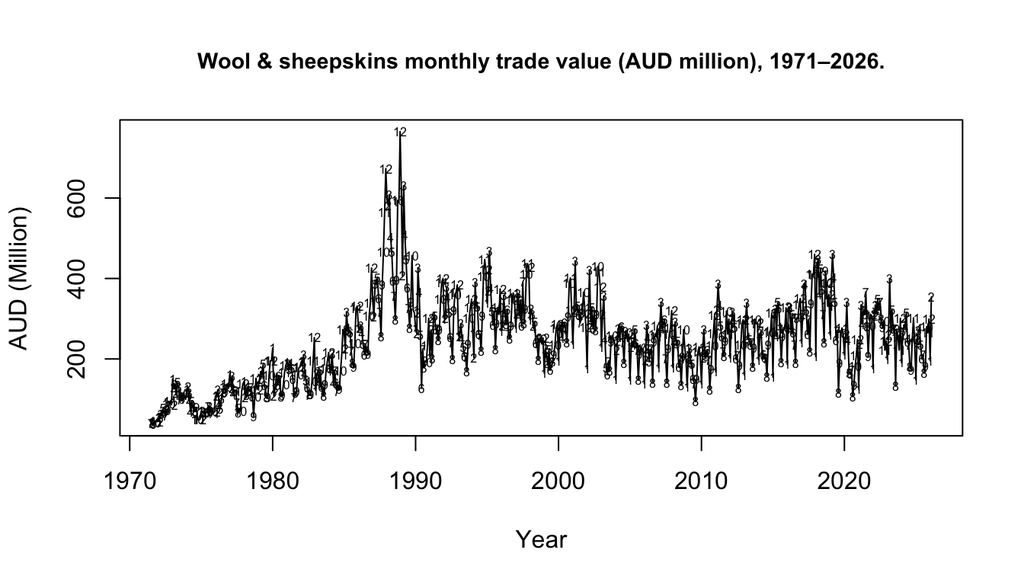

Figure 1: Wool & sheepskins monthly trade value (AUD million), 1971–2026.

```r
plot(WoolTS, type = "l", ylab = "AUD (Million)", xlab = "Year", cex.main = 0.9,
     main = "Wool & sheepskins monthly trade value (AUD million), 1971–2026.")

month_num <- cycle(WoolTS)
text(x = time(WoolTS), y = WoolTS, labels = month_num, cex = 0.5)
```

Figure 1 shows the time series plot of the wool & sheepskins monthly trade value. Several features stand out:

1. **Trend.** The series exhibits a pronounced stochastic **upward trend** from 1971 through the late 1980s, peaking around 1988–1989, followed by a prolonged decline through the early 1990s, after which the series settles into a lower but more stable level, with a secondary elevation visible around 2018–2021.
2. **Seasonality:** Regular within-year oscillations are visible throughout the entire sample. December (12) frequently coincides with peak trade values, while August (8) is commonly observed at low points. These recurring annual cycles confirm that a **SARIMA model with seasonal period** $s = 12$ months is appropriate.
3. **Non-constant variance:** The amplitude of fluctuations is substantially larger during the 1985–1991 commodity boom than in the surrounding decades. This **heteroscedasticity** suggests that a variance-stabilising transformation should be applied before modelling.
4. **Change Point:** The series exhibits a stark structural intervention around February 1991, representing the catastrophic collapse of the Australian Wool Corporation’s Reserve Price Scheme. This intervention permanently altered the long-term trend line.
5. **Autocorrelation:** The series shows **strong autocorrelation**, with consecutive monthly values tending to move together, which will be formally assessed using ACF/PACF plots.

## 2.2 Summary Statistics

Table 2 presents descriptive statistics for the series.

```r
Summary <- c(
  Mean            = round(mean(WoolTS),                2),
  Median          = round(median(WoolTS),              2),
  "Std. Dev."     = round(sd(WoolTS),                  2),
  Minimum         = round(min(WoolTS),                 2),
  Maximum         = round(max(WoolTS),                 2),
  Range           = round(max(WoolTS) - min(WoolTS),   2),
  "N (obs.)"      = length(WoolTS)
)

knitr::kable(
  t(as.data.frame(Summary)),
  align = "c"
)
```

Table 2: Descriptive statistics for monthly wool and sheepskins trade value (AUD million).

|  | Mean | Median | Std. Dev. | Minimum | Maximum | Range | N (obs.) |
| --- | --- | --- | --- | --- | --- | --- | --- |
| Summary | 242.49 | 243.5 | 105.88 | 38 | 765 | 727 | 656 |

The mean (242.5 AUD million) and median (243.5 AUD million) are close, but the standard deviation (105.88 AUD million), roughly 45% of the mean, signals **high** dispersion. These features motivate both a variance-stabilising transformation and formal stationarity testing.

## 2.3 Distributional Diagnostics

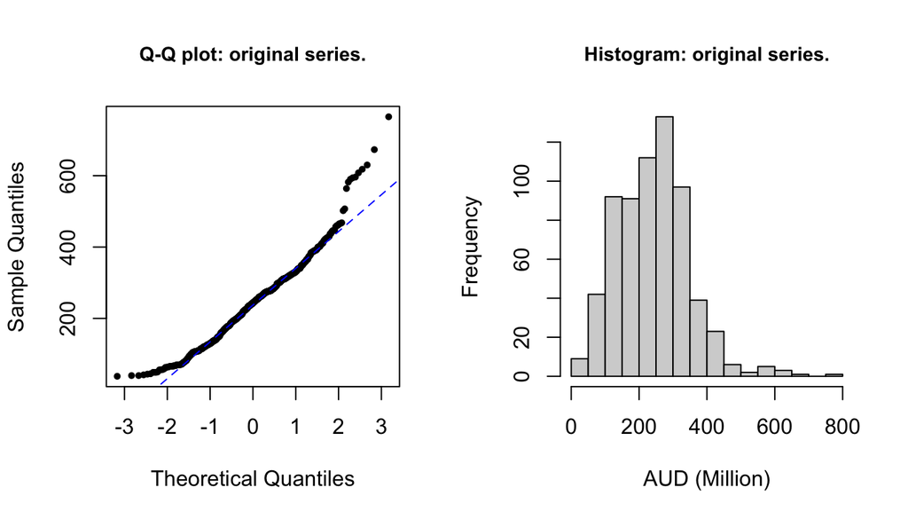

Figure 2: Q-Q plot (left) and histogram (right) of the original series.

```r
plot_norm(WoolTS,
          qq_title   = "Q-Q plot: original series.",
          hist_title = "Histogram: original series.")
```

```r
sw_orig <- run_sw(WoolTS, "Shapiro-Wilk normality test: original series.")
sw_orig$table
```

Table 3: Shapiro-Wilk normality test: original series.

Shapiro-Wilk normality test: original series.

| W statistic | p-value |
| --- | --- |
| 0.9682 | 9.88e-11 |

Figure 2 and Table 3 confirm distributional non-normality. The Q-Q plot shows pronounced upper-tail deviation from the reference line. The histogram displays a unimodal but right-skewed distribution. The **Shapiro-Wilk test** yields $W = 0.9682$ with $p = 9.88e-11$; since this is **below** $\alpha = 0.05$, we **reject the null hypothesis of normality**. This, combined with the visual evidence of heteroscedasticity, motivates applying a **variance-stabilising power transformation** before proceeding.

## 2.4 Autocorrelation Function (ACF) & Partial Autocorrelation Function (PACF)

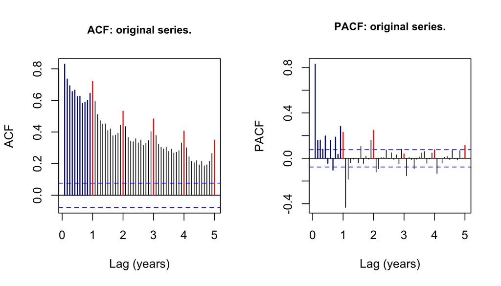

Figure 3: ACF (left) and PACF (right) of the original series.

```r
plot_seasonal_acf_pacf(
  WoolTS,
  acf_title  = "ACF: original series.",
  pacf_title = "PACF: original series."
)
```

For this monthly data, lags are expressed in years (e.g., lag 1 = 12 months). Three features stand out in Figure 3:

1. **Non-stationarity (slow ACF decay).** The ACF decays very slowly — the canonical signature of a non-stationary mean.
2. **AR(1)-type partial autocorrelation.** The PACF exhibits a dominant spike at lag 1 followed by an abrupt cutoff.
3. **Seasonal spikes.** Elevated ACF and PACF values at lags 12, 24, and 36 (highlighted in red) confirm a significant seasonal periodic component at $s = 12$ months.

```r
adf_orig <- run_adf(WoolTS, "Augmented Dickey-Fuller test: original series.")
adf_orig$table
```

Table 4: Augmented Dickey-Fuller test: original series.

Augmented Dickey-Fuller test: original series.

| Dickey-Fuller statistic | Lags used | p-value |
| --- | --- | --- |
| -3.3357 | 8 | 6.45e-02 |

The **ADF test** (Table 4) returns a Dickey-Fuller statistic of -3.3357 with $p = 6.45e-02$. Because this p-value exceeds 0.05, we **fail to reject the null hypothesis of a unit root**, statistically confirming the series is non-stationary and that **differencing will be required**.

# 3 Data Transformation

Before applying differencing to remove the trend, we first address the non-constant variance. The Box-Cox transformation is applied for this purpose.

## 3.1 Optimal $\lambda$ Selection

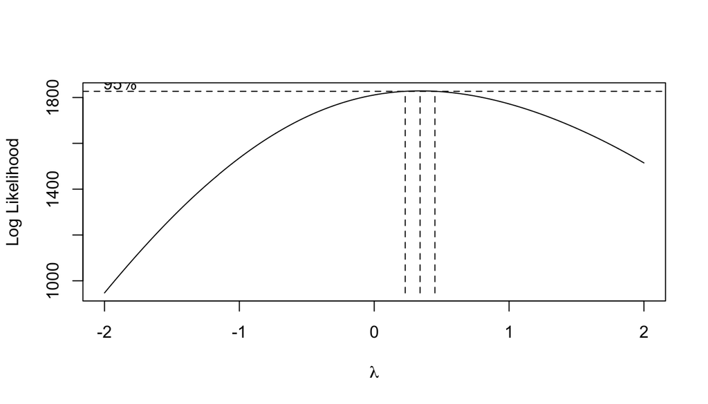

Figure 4: Box-Cox log-likelihood profile for optimal lambda selection.

```r
BC           <- BoxCox.ar(y = WoolTS, lambda = seq(-2, 2, 0.01),
                          method = "yule-walker")
lambda_opt   <- BC$lambda[which.max(BC$loglike)]
lambda_lower <- BC$ci[1]
lambda_upper <- BC$ci[3]
```

```r
BC_WoolTS <- (WoolTS^lambda_opt - 1) / lambda_opt

knitr::kable(
  data.frame(
    Parameter = c("Optimal Lambda", "95% CI lower bound", "95% CI upper bound"),
    Value     = round(c(lambda_opt, lambda_lower, lambda_upper), 4)),
  align = "lc", row.names = FALSE, booktabs = TRUE)
```

Table 5: Box-Cox parameter estimates for the wool trade series.

| Parameter | Value |
| --- | --- |
| Optimal Lambda | 0.34 |
| 95% CI lower bound | 0.23 |
| 95% CI upper bound | NA |

Table 5 shows the optimal $\lambda$ = 0.34, with a 95% confidence interval of [0.23, NA]. The upper bound could not be reliably estimated, but the lower bound confirms that $\lambda = 1$ (no transformation) lies outside the interval. The estimated $\lambda = 0.34$ is closer to a cube-root transformation ($\lambda = 1/3$) than to the more common log ($\lambda = 0$) or square-root ($\lambda = 0.5$) transformations.

## 3.2 Transformed Series Diagnostics

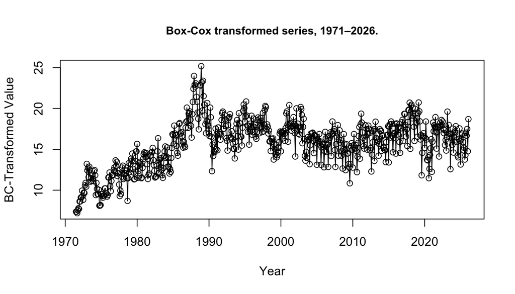

Figure 5: Box-Cox transformed series (λ = 0.34), 1971–2026.

```r
plot_ts(BC_WoolTS,
        main = "Box-Cox transformed series, 1971–2026.",
        ylab = "BC-Transformed Value")
```

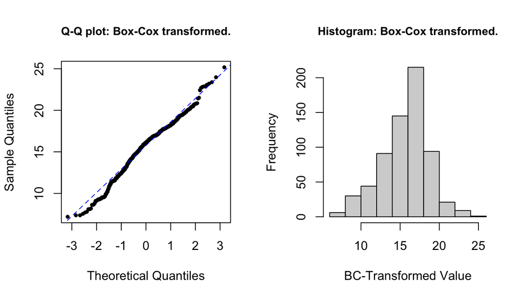

Figure 6: Q-Q plot (left) and histogram (right) of the Box-Cox transformed series.

```r
plot_norm(BC_WoolTS,
          qq_title   = "Q-Q plot: Box-Cox transformed.",
          hist_title = "Histogram: Box-Cox transformed.",
          xlab       = "BC-Transformed Value")
```

```r
sw_bc <- run_sw(BC_WoolTS, "Shapiro-Wilk normality test: Box-Cox transformed series.")
sw_bc$table
```

Table 6: Shapiro-Wilk normality test: Box-Cox transformed series.

Shapiro-Wilk normality test: Box-Cox transformed series.

| W statistic | p-value |
| --- | --- |
| 0.9817 | 2.53e-07 |

The Shapiro-Wilk test yields W = 0.98 with p = 2.53e-07 (< 0.05), leading to rejection of normality. Despite this, the transformation has improved the distributional characteristics. Although SARIMA modelling does not strictly require data normality, the Box-Cox transformation significantly improved the series’ stationarity and variance characteristics. We therefore proceed with the transformed data for the remaining analysis.

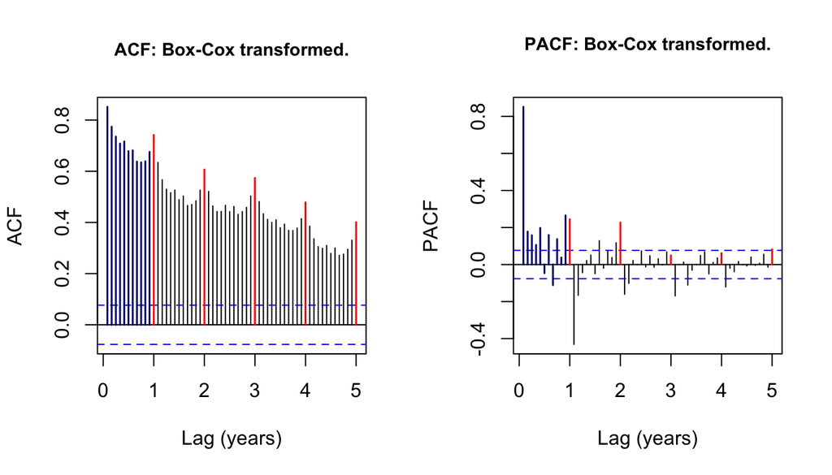

Figure 7: ACF (left) and PACF (right) of the Box-Cox transformed series.

```r
plot_seasonal_acf_pacf(
  BC_WoolTS,
  acf_title  = "ACF: Box-Cox transformed.",
  pacf_title = "PACF: Box-Cox transformed.")
```

After Box-Cox transformation, both the non-seasonal unit root (slow ACF decay) and the seasonal unit root (spikes at lags 1, 2, and 3 corresponding to 12, 24, and 36 months) **still remain**. The PACF shows a dominant spike at lag 1 followed by a **sharp cutoff**, suggesting an AR(1) structure is required after differencing.

## 3.3 Summary of Transformation Diagnostics

```r
comparison_df <- data.frame(
  "Diagnostic" = c("Shapiro-Wilk W statistic",
                   "Shapiro-Wilk p-value",
                   "ADF Dickey-Fuller statistic",
                   "ADF p-value"),
  "Original series" = c(
    round(sw_orig$result$statistic, 4),
    format(sw_orig$result$p.value,  scientific = TRUE, digits = 3),
    round(as.numeric(adf_orig$result$statistic), 4),
    format(adf_orig$result$p.value, scientific = TRUE, digits = 3)),
  "Box-Cox transformed" = c(
    round(sw_bc$result$statistic, 4),
    format(sw_bc$result$p.value,  scientific = TRUE, digits = 3),
    round(as.numeric({adf_bc <- adf.test(BC_WoolTS); adf_bc}$statistic), 4),
    format(adf_bc$p.value,        scientific = TRUE, digits = 3)),
  check.names = FALSE)

knitr::kable(comparison_df, align = "lcc", row.names = FALSE, booktabs = TRUE)
```

Table 7: Comparison of normality and stationarity diagnostics before and after Box-Cox transformation.

| Diagnostic | Original series | Box-Cox transformed |
| --- | --- | --- |
| Shapiro-Wilk W statistic | 0.9682 | 0.9817 |
| Shapiro-Wilk p-value | 9.88e-11 | 2.53e-07 |
| ADF Dickey-Fuller statistic | -3.3357 | -3.4379 |
| ADF p-value | 6.45e-02 | 4.83e-02 |

Table 7 summarises the effect of the Box-Cox transformation. The Shapiro-Wilk statistic improved from 0.9682 (original) to 0.9817 (transformed). The ADF test p-value decreased from 0.0645 (original) to 0.0483 (transformed), crossing the 0.05 significance threshold. This suggests that the Box-Cox transformation has helped stabilize both the variance and, to some extent, the mean. However, the ACF still exhibits slow decay, indicating that differencing remains necessary.

# 4 Model Specification: Residual Approach

Rather than searching the full SARIMA$(p,d,q)(P,D,Q)_{12}$ parameter space simultaneously, we adopt a **sequential residual approach**, building the model structure one component at a time and validating each stage through residual diagnostics. The approach proceeds in the following steps:

1. **Seasonal Differencing** $(D)$: Apply seasonal difference and inspect residual ACF and PACF to determine whether the seasonal unit root has been removed and to identify the required seasonal ARMA order $(P, Q)$.
2. **Seasonal ARMA Specification** $(P, Q)$: Augment with seasonal ARMA terms and inspect updated residuals. Apply formal stationarity tests (ADF, PP, KPSS) to assess whether non-seasonal differencing is required.
3. **Non-Seasonal Differencing and ARMA Diagnostics** $(d)$: Apply non-seasonal differencing and inspect residual ACF and PACF to confirm the mean has been stabilised.
4. **Full Model Autocorrelation Check**: Fit a trial model incorporating both non-seasonal AR and MA terms to verify that the complete SARIMA$(p,d,q)(P,D,Q)_{12}$ framework is sufficient to reduce the residuals to white noise.
5. **Non-Seasonal ARMA Order Identification**: Apply three complementary identification tools (ACF/PACF, EACF, BIC subset selection) to enumerate candidate non-seasonal orders.

## 4.1 Step 1 — Seasonal Differencing: SARIMA$(0,0,0)(0,1,0)_{12}$

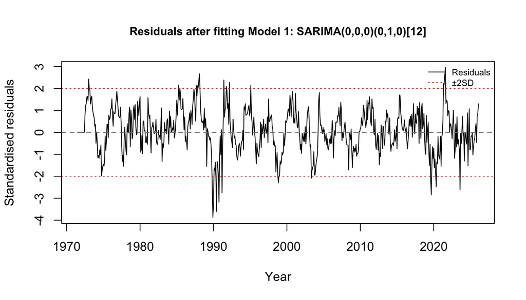

Figure 8: Residuals after fitting Model 1: SARIMA(0,0,0)(0,1,0)[12].

```r
m1_wool <- Arima(BC_WoolTS, order = c(0, 0, 0),
                 seasonal = list(order = c(0, 1, 0), period = 12))
res_m1  <- rstandard(m1_wool)

plot(res_m1, type = "l", cex = 0.4, pch = 16, cex.main = 0.9,
     xlab = "Year", ylab = "Standardised residuals",
     main = "Residuals after fitting Model 1: SARIMA(0,0,0)(0,1,0)[12]")
abline(h = c(0, 2, -2), col = c("grey50", "red", "red"), lty = c(2, 3, 3))
legend("topright", legend = c("Residuals", "±2SD"),
       col = c("black", "red"), lty = c(1, 3), cex = 0.7, bty = "n")
```

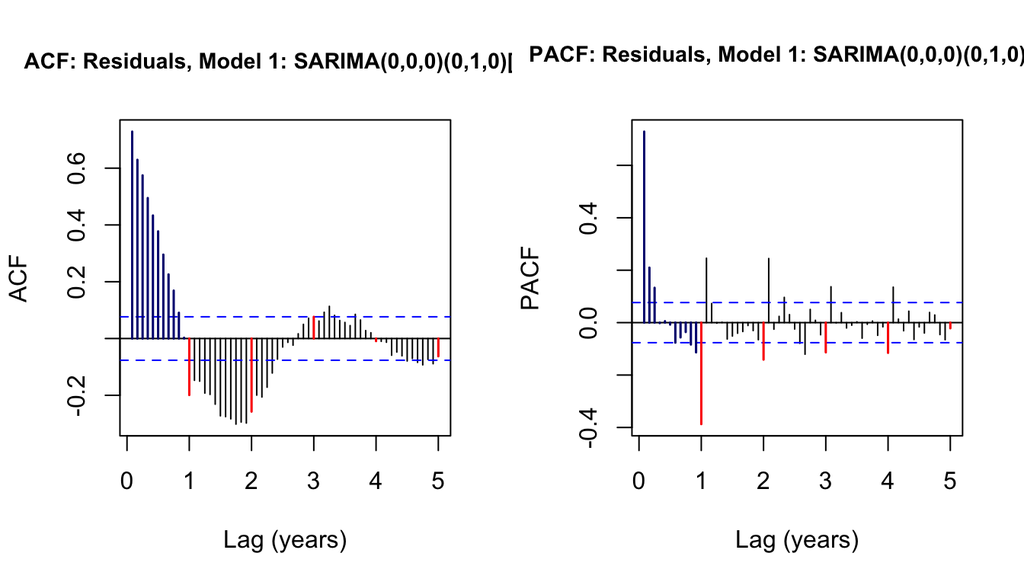

Figure 9: ACF (left) and PACF (right) of residuals from Model 1: SARIMA(0,0,0)(0,1,0)[12].

```r
plot_seasonal_acf_pacf(
  res_m1,
  acf_title  = "ACF: Residuals, Model 1: SARIMA(0,0,0)(0,1,0)[12]",
  pacf_title = "PACF: Residuals, Model 1: SARIMA(0,0,0)(0,1,0)[12]")
```

Applying one seasonal difference ($D = 1$) to the Box-Cox transformed series removes much of the seasonal oscillation, as evidenced by the roughly zero-centred path in Figure 8. Even so, seasonal differencing alone is insufficient to fully eliminate the seasonal dependence, meaning seasonal ARMA terms are required to capture the remaining structure.

Looking at the diagnostics, the ACF in Figure 9 shows **significant seasonal spikes at lags 12 and 24** remaining well above the significance bands, while the PACF shows **slowly decaying seasonal spikes**. Consequently, we choose seasonal moving average order $Q = 2$ and seasonal autoregressive order $P = 0$.

## 4.2 Step 2 — Seasonal ARMA Specification: SARIMA$(0,0,0)(0,1,2)_{12}$

The seasonal ACF in Figure 9 showed **two significant spikes at seasonal lags 1 and 2** (corresponding to 12 and 24 months), which is the signature of a seasonal MA(2) process. The PACF showed slowly decaying seasonal lags, ruling out a seasonal AR component ($P = 0$). Accordingly, SMA(2) terms are added, fixing the seasonal structure at $(0,1,2)_{12}$ for all subsequent models. This give us: SARIMA$(0,0,0)(0,1,2)_{12}$.

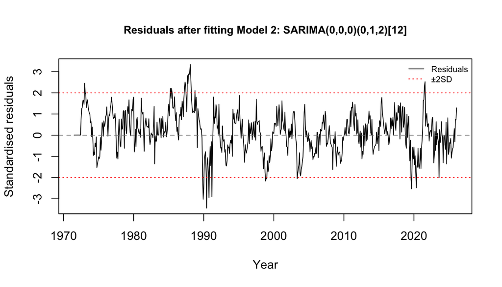

Figure 10: Residuals after fitting Model 2: SARIMA(0,0,0)(0,1,2)[12].

```r
m2_wool <- Arima(BC_WoolTS, order = c(0, 0, 0),
                 seasonal = list(order = c(0, 1, 2), period = 12))
res_m2  <- rstandard(m2_wool)

plot(res_m2, type = "l", cex = 0.4, pch = 16, cex.main = 0.9,
     xlab = "Year", ylab = "Standardised residuals",
     main = "Residuals after fitting Model 2: SARIMA(0,0,0)(0,1,2)[12]")
abline(h = c(0, 2, -2), col = c("grey50", "red", "red"), lty = c(2, 3, 3))
legend("topright", legend = c("Residuals", "±2SD"),
       col = c("black", "red"), lty = c(1, 3), cex = 0.7, bty = "n")
```

After fitting Model 2, SARIMA$(0,0,0)(0,1,2)_{12}$, Figure 10 shows residuals are better behaved. Nevertheless, the **footprint of historical shocks remains prominent**, with extreme excursions still reaching the ±3 standard deviation threshold. Outside these extreme period, most standardised residuals lie within the ±2 standard deviation bounds.

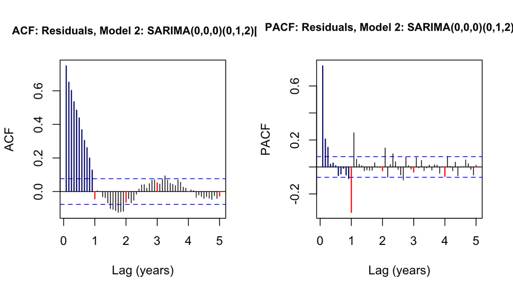

Figure 11: ACF (left) and PACF (right) of residuals from Model 2: SARIMA(0,0,0)(0,1,2)[12].

```r
plot_seasonal_acf_pacf(
  res_m2,
  acf_title  = "ACF: Residuals, Model 2: SARIMA(0,0,0)(0,1,2)[12]",
  pacf_title = "PACF: Residuals, Model 2: SARIMA(0,0,0)(0,1,2)[12]")
```

The ACF in Figure 11 confirms the seasonal spikes at lags 12 and 24 now fall within the confidence bands — **the SMA(2) term has absorbed the remaining seasonal autocorrelation**. The seasonal component is therefore fixed at $(0,1,2)_{12}$ for all subsequent candidate models.

However, the ordinary (non-seasonal) lags reveal **remaining short-term structure**: the ACF shows **slow decay** and the PACF shows a **dominant spike** at ordinary lag 1 followed by a cutoff, indicating non-seasonal autocorrelation is still present. This suggests that non-seasonal differencing $(d=1)$ is required to stabilize the mean. So we run formal stationarity tests (Table 8) to confirm this.

```r
adf_resm2 <- check_stationarity(
  res_m2,
  "Formal statistical verification of stationarity for residuals of Model 2."
)
adf_resm2$table
```

Table 8: Formal stationarity tests for residuals of Model 2.

Formal statistical verification of stationarity for residuals of Model 2.

| Statistical Test | Null Hypothesis (H0) | Test Statistic | p-value | Result |
| --- | --- | --- | --- | --- |
| Augmented Dickey-Fuller (ADF) | Series is non-stationary | -5.8003 | 0.01 | Reject H0 (Stationary) |
| Phillips-Perron (PP) | Series is non-stationary | -172.4610 | 0.01 | Reject H0 (Stationary) |
| KPSS Test | Series is stationary | 0.7550 | 0.01 | Reject H0 (Non-Stationary) |

When running formal statistical tests to confirm the stationarity of the series, the result (Table 8) presents a classic contradiction. The ADF and PP tests reject the unit root hypothesis (indicating stationarity), while the KPSS test rejects the null of stationarity (indicating non-stationarity). Based on the persistent decay in the ACF plot, the sharp cutoff in the PACF, and the KPSS test confirming non-stationarity in the levels, a first-difference $d = 1$ conservatively, establishing the baseline structural framework as **SARIMA**$(p,1,q)(0,1,2)_{12}$.

## 4.3 Step 3 — Non-Seasonal Differencing & ARMA Diagnostics

Based on the contradictory stationarity test results from Step 2 and the visual evidence of remaining non-seasonal autocorrelation, a non-seasonal difference ($d = 1$) is applied conservatively. This produces the baseline structural framework **SARIMA**$(0,1,0)(0,1,2)_{12}$, from which all **subsequent candidate models will be built**.

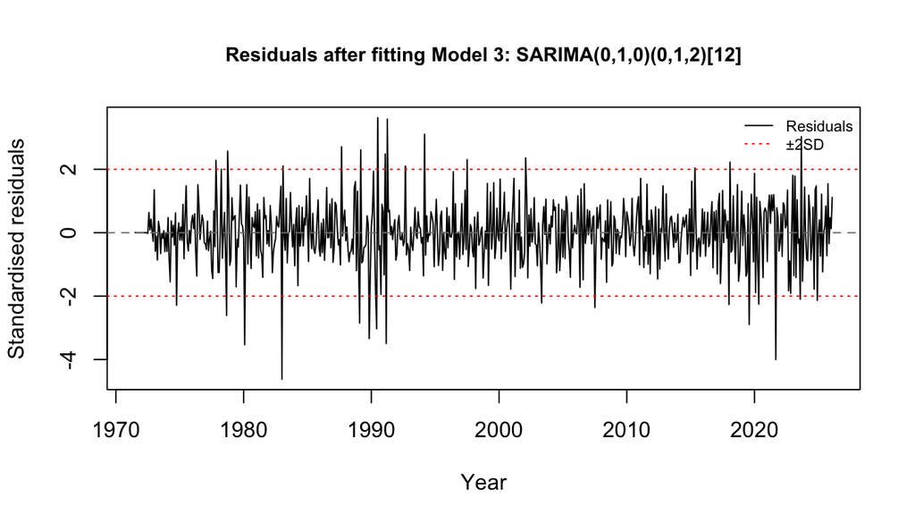

Figure 12: Residuals after fitting Model 3: SARIMA(0,1,0)(0,1,2)[12].

```r
m3_wool <- Arima(BC_WoolTS, order = c(0, 1, 0),
                 seasonal = list(order = c(0, 1, 2), period = 12))
res_m3  <- rstandard(m3_wool)

plot(res_m3, type = "l", cex = 0.4, pch = 16, cex.main = 0.9,
     xlab = "Year", ylab = "Standardised residuals",
     main = "Residuals after fitting Model 3: SARIMA(0,1,0)(0,1,2)[12]")
abline(h = c(0, 2, -2), col = c("grey50", "red", "red"), lty = c(2, 3, 3))
legend("topright", legend = c("Residuals", "±2SD"),
       col = c("black", "red"), lty = c(1, 3), cex = 0.7, bty = "n")
```

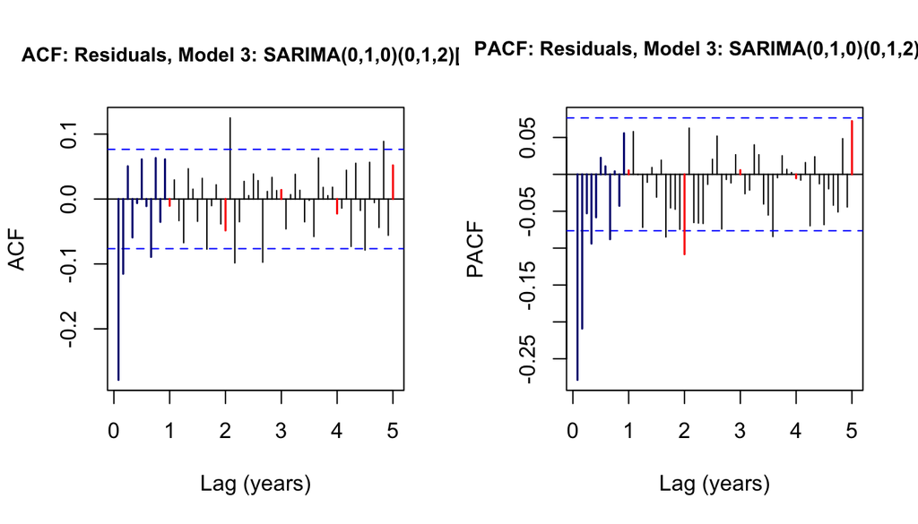

Figure 13: ACF (left) and PACF (right) of residuals from Model 3: SARIMA(0,1,0)(0,1,2)[12].

```r
plot_seasonal_acf_pacf(
  res_m3,
  acf_title  = "ACF: Residuals, Model 3: SARIMA(0,1,0)(0,1,2)[12]",
  pacf_title = "PACF: Residuals, Model 3: SARIMA(0,1,0)(0,1,2)[12]")
```

Figure Figure 13 presents the ACF and PACF of the residuals for Model 3 SARIMA$(0,1,0)(0,1,2)_{12}$. The dominant seasonal spikes have been removed, **confirming that the seasonal structure** $(0,1,2)_{12}$ and the non-seasonal differencing ($d = 1$) have together absorbed seasonal and trend-related autocorrelation.

However, a detailed inspection of the ordinary (non-seasonal) lags reveals remaining short-term dependence, **confirming that p and q are not yet specified**. Both the ACF and PACF in Figure 13 show approximately 3 significant spikes at ordinary lags, after which correlations fall within the confidence bands, giving a preliminary indication that both $p$ and $q$ are in the range of 1–3.

Consequently, the Model 3 residuals, with seasonal structure, seasonal autocorrelation ($P = 0, D = 1, Q = 2$) , and non-seasonal trend ($d = 1$) all removed, now contain only the **short-term non-seasonal ARMA(p,q) dependence**. These residuals are therefore the correct and necessary input for the formal order identification tools for Step 5.

## 4.4 Step 4 — Full Model Autocorrelation Check

To validate that the SARIMA$(p,1,q)(0,1,2)_{12}$ framework is sufficient to fully capture all remaining autocorrelation, Model 4, SARIMA$(2,1,2)(0,1,2)_{12}$, is fitted as a **diagnostic trial, using (**$p = 2$) and ($q = 2$) to directly address the approximate 3 significant spikes observed in both the ACF and PACF of the Model 3 residuals (Figure 13).

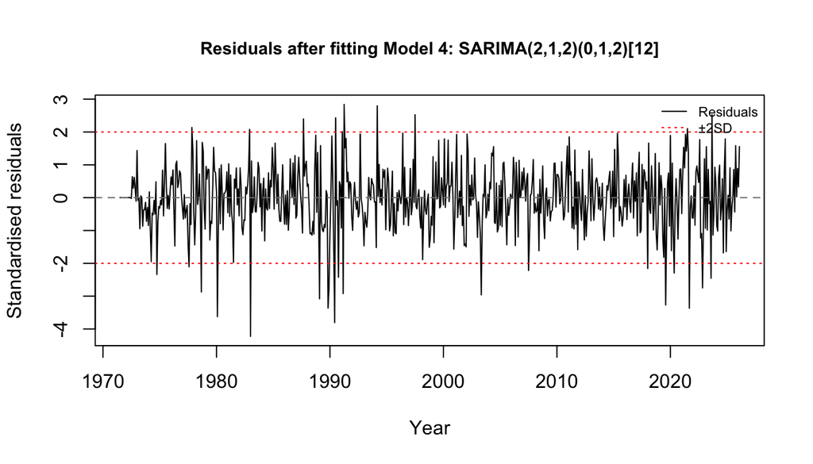

Figure 14: Residuals after fitting Model 4: SARIMA(2,1,2)(0,1,2)[12].

```r
m4_wool <- Arima(BC_WoolTS, order = c(2, 1, 2),
                 seasonal = list(order = c(0, 1, 2), period = 12))
res_m4  <- rstandard(m4_wool)

plot(res_m4, type = "l", cex = 0.4, pch = 16, cex.main = 0.9,
     xlab = "Year", ylab = "Standardised residuals",
     main = "Residuals after fitting Model 4: SARIMA(2,1,2)(0,1,2)[12]")
abline(h = c(0, 2, -2), col = c("grey50", "red", "red"), lty = c(2, 3, 3))
legend("topright", legend = c("Residuals", "±2SD"),
       col = c("black", "red"), lty = c(1, 3), cex = 0.7, bty = "n")
```

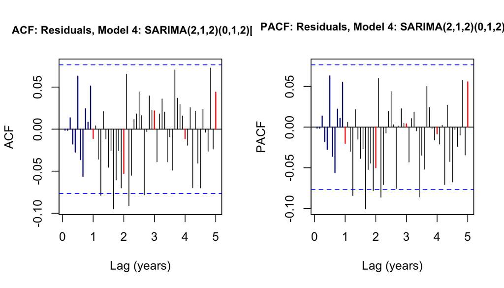

Figure 15: ACF (left) and PACF (right) of residuals from Model 4: SARIMA(2,1,2)(0,1,2)[12].

```r
plot_seasonal_acf_pacf(
  res_m4,
  acf_title  = "ACF: Residuals, Model 4: SARIMA(2,1,2)(0,1,2)[12]",
  pacf_title = "PACF: Residuals, Model 4: SARIMA(2,1,2)(0,1,2)[12]")
```

Figure 15 confirms the absence of any systematic patterns or persistent autocorrelation at either ordinary or seasonal lags, **indicating that the residuals have been successfully reduced to white noise**. This validates that the SARIMA$(p,1,q)(0,1,2)_{12}$ framework is sufficient to fully capture the series structure.

## 4.5 Step 5 — Non-Seasonal ARMA Order Identification

Following the elimination of all seasonal dynamics and non-seasonal trends, the Model 3 residuals contain only the isolated, pure non-seasonal ARMA(p,q) signal. To identify the optimal order for this remaining process, we deploy three complementary identification tools, beginning with the **visual diagnostics provided by the (Model 3) residual ACF and PACF plots in Figure 13**.

### 4.5.1 ACF & PACF of the Model 3 Residuals

Combining these ranges gives 9 ACF/PACF-derived candidate structures:

- SARIMA$(1,1,1)(0,1,2)_{12}$
- SARIMA$(1,1,2)(0,1,2)_{12}$
- SARIMA$(1,1,3)(0,1,2)_{12}$
- SARIMA$(2,1,1)(0,1,2)_{12}$
- SARIMA$(2,1,2)(0,1,2)_{12}$
- SARIMA$(2,1,3)(0,1,2)_{12}$
- SARIMA$(3,1,1)(0,1,2)_{12}$
- SARIMA$(3,1,2)(0,1,2)_{12}$
- SARIMA$(3,1,3)(0,1,2)_{12}$

### 4.5.2 EACF Analysis of the Model 3 Residuals

However, as established in Step 3, the presence of spikes in both plots simultaneously indicates a mixed ARMA process where exact orders cannot be determined by visual inspection alone. **EACF and BIC are required**.

The EACF is applied to the residuals of Model 3 SARIMA$(0,1,0)(0,1,2)_{12}$. Because Model 3 has already filtered out the seasonal structure $(0,1,2)_{12}$ and non-seasonal trend $(d=1)$ have already been filtered, the remaining information in these **residuals belongs entirely to the short-term non-seasonal ARMA(p,q) process**, making them the correct input for order identification.

```r
eacf_res <- eacf(res_m3, ar.max = 7, ma.max = 13)
```

```
AR/MA
  0 1 2 3 4 5 6 7 8 9 10 11 12 13
0 x x o o o o o x o o o  o  o  o
1 x x o o o o o x o o o  o  o  o
2 x x x x o o o x o o o  o  o  o
3 x x x x o o o o o o o  o  o  o
4 x x x x o o o o o o o  o  o  o
5 x x x x o o o o o o o  o  o  o
6 x o x x x x o o o o o  o  o  o
7 x x x x x x o x o o o  o  o  o
```

The EACF is read by locating the upper-left vertex of the triangle of ‘o’ values. The first stable triangle has its vertex at AR=0, MA=2, identifying **ARMA(0,2)** as the most parsimonious candidate. The ‘o’ pattern also holds at AR=0, MA=3; AR=1, MA=2; and AR=1, MA=3. These four EACF-derived candidates correspond to

- SARIMA$(0,1,2)(0,1,2)_{12}$
- SARIMA$(0,1,3)(0,1,2)_{12}$
- SARIMA$(1,1,2)(0,1,2)_{12}$
- SARIMA$(1,1,3)(0,1,2)_{12}$

### 4.5.3 BIC Subset-Selection Plot of the Model 3 Residuals

To complement the EACF analysis, BIC subset-selection plots were generated to identify the most promising non-seasonal ARMA orders. These plots display BIC values for different combinations of AR(p) and MA(q) orders, with darker cells indicating lower(BIC) values. Figure 16 and 17 present the results for two different search ranges (nar = 10, nma = 10, and nar =5, nma = 5)

```r
res_bic <- armasubsets(y = res_m3, nar = 10, nma = 10,
                       y.name = "res", ar.method = "ols")
```

```
Reordering variables and trying again:
```

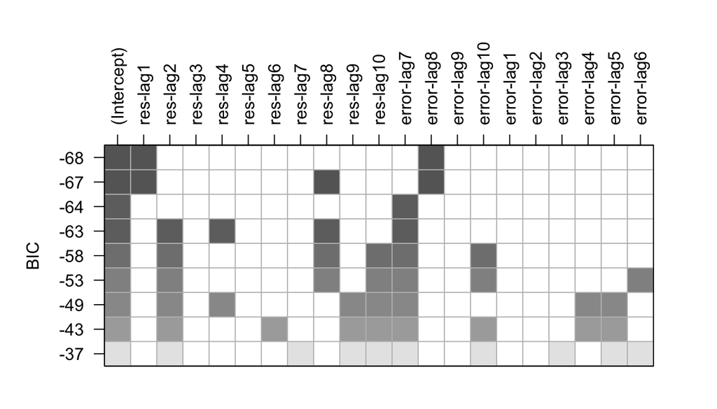

Figure 16: BIC subset-selection plot (AR max = 10, MA max = 10).

```r
plot(res_bic)
```

The BIC subset-selection plots are generated across two search ranges to assess stability of the results. The wider search selects high MA orders up to lag 8, which are theoretically implausible for this series and likely reflect overfitting across the larger search space. **These results are therefore not carried forward as candidates**.

```r
res_bic2 <- armasubsets(y = res_m3, nar = 5, nma = 5,
                        y.name = "res", ar.method = "ols")
```

```
Reordering variables and trying again:
```

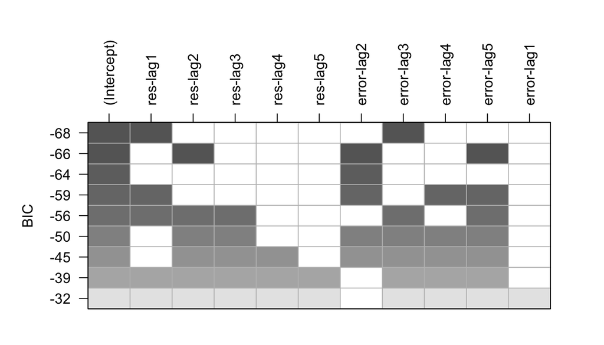

Figure 17: BIC subset-selection plot (AR max = 5, MA max = 5).

```r
plot(res_bic2)
```

The narrower search, on the other hand, produces more reliable and practically meaningful results. The best model includes AR lag 1 and MA lag 3, corresponding to ARMA(1,3) giving SARIMA$(1,1,3)(0,1,2)_{12}$ as the **primary BIC-derived candidate**. The second row includes AR lag 2 and MA lag 2 and 5, corresponding to ARMA(2,2) and ARMA(2,5). But ARMA(2,5) is not carried forward as a candidate. BIC-derived candidates are therefore:

- SARIMA$(1,1,3)(0,1,2)_{12}$
- SARIMA$(2,1,2)(0,1,2)_{12}$

# 5 Model Fitting

Together, the three identification methods yield **11 candidate SARIMA models** for evaluation. All subsequent SARIMA models are fitted to the original `WoolTS` series with the optimal Box-Cox lambda (0.34) passed via the `lambda` argument to `Arima()`, which applies the Box-Cox transformation internally and back-transforms forecasts automatically onto the original scale.

**Important**

**Why models are fitted to the original series, not the transformed series?**

In time-series modeling the model should be fitted to the **original series** while passing the transformation parameter (λ) internally, rather than fitting a model directly to a pre-transformed series. Otherwise, it will introduces one or two of these following errors:

- **Double Transformation:** Passing a pre-transformed series into a modeling function with the (λ) argument enabled causes the function to apply the Box-Cox power a second time. This results in a mathematically invalid, over-transformed input scale.
- **Double Differencing:** Any specified differencing operators (d,D) would then execute on this doubly-transformed data. Relative to the true data structure, this removes far more variation than intended, distorting the autocorrelation structure and biasing all subsequent parameter estimates.

```r
candidate_models <- data.frame(
  Label = c("M012", "M013", "M111", "M112", "M113", "M211",
            "M212", "M213", "M311", "M312", "M313"),
  Specification = c(
    "SARIMA$(0,1,2)(0,1,2)_{12}$",
    "SARIMA$(0,1,3)(0,1,2)_{12}$",
    "SARIMA$(1,1,1)(0,1,2)_{12}$",
    "SARIMA$(1,1,2)(0,1,2)_{12}$",
    "SARIMA$(1,1,3)(0,1,2)_{12}$",
    "SARIMA$(2,1,1)(0,1,2)_{12}$",
    "SARIMA$(2,1,2)(0,1,2)_{12}$",
    "SARIMA$(2,1,3)(0,1,2)_{12}$",
    "SARIMA$(3,1,1)(0,1,2)_{12}$",
    "SARIMA$(3,1,2)(0,1,2)_{12}$",
    "SARIMA$(3,1,3)(0,1,2)_{12}$"
  ),
  Methods = c(
    "EACF",
    "EACF",
    "ACF/PACF",
    "ACF/PACF, EACF",
    "ACF/PACF, EACF, BIC",
    "ACF/PACF",
    "ACF/PACF, BIC",
    "ACF/PACF",
    "ACF/PACF",
    "ACF/PACF",
    "ACF/PACF"
  )
)

kable(candidate_models,
      align = c("l", "l", "l"),
      escape = FALSE,
      booktabs = TRUE) |>
  kable_styling(latex_options = c("hold_position", "striped"))
```

Table 9: Candidate SARIMA models carried forward for estimation.

| Label | Specification | Methods |
| --- | --- | --- |
| M012 | SARIMA$(0,1,2)(0,1,2)_{12}$ | EACF |
| M013 | SARIMA$(0,1,3)(0,1,2)_{12}$ | EACF |
| M111 | SARIMA$(1,1,1)(0,1,2)_{12}$ | ACF/PACF |
| M112 | SARIMA$(1,1,2)(0,1,2)_{12}$ | ACF/PACF, EACF |
| M113 | SARIMA$(1,1,3)(0,1,2)_{12}$ | ACF/PACF, EACF, BIC |
| M211 | SARIMA$(2,1,1)(0,1,2)_{12}$ | ACF/PACF |
| M212 | SARIMA$(2,1,2)(0,1,2)_{12}$ | ACF/PACF, BIC |
| M213 | SARIMA$(2,1,3)(0,1,2)_{12}$ | ACF/PACF |
| M311 | SARIMA$(3,1,1)(0,1,2)_{12}$ | ACF/PACF |
| M312 | SARIMA$(3,1,2)(0,1,2)_{12}$ | ACF/PACF |
| M313 | SARIMA$(3,1,3)(0,1,2)_{12}$ | ACF/PACF |

```r
# M012
m012_css <- Arima(WoolTS, order = c(0,1,2),
                  seasonal = list(order = c(0,1,2), period = 12),
                  method = "CSS", lambda = lambda_opt)
m012_ml  <- Arima(WoolTS, order = c(0,1,2),
                  seasonal = list(order = c(0,1,2), period = 12),
                  method = "ML", lambda = lambda_opt)

# M013
m013_css <- Arima(WoolTS, order = c(0,1,3),
                  seasonal = list(order = c(0,1,2), period = 12),
                  method = "CSS", lambda = lambda_opt)
m013_ml  <- Arima(WoolTS, order = c(0,1,3),
                  seasonal = list(order = c(0,1,2), period = 12),
                  method = "ML", lambda = lambda_opt)

# M111
m111_css <- Arima(WoolTS, order = c(1,1,1),
                  seasonal = list(order = c(0,1,2), period = 12),
                  method = "CSS", lambda = lambda_opt)
m111_ml  <- Arima(WoolTS, order = c(1,1,1),
                  seasonal = list(order = c(0,1,2), period = 12),
                  method = "ML", lambda = lambda_opt)

# M112
m112_css <- Arima(WoolTS, order = c(1,1,2),
                  seasonal = list(order = c(0,1,2), period = 12),
                  method = "CSS", lambda = lambda_opt)
m112_ml  <- Arima(WoolTS, order = c(1,1,2),
                  seasonal = list(order = c(0,1,2), period = 12),
                  method = "ML", lambda = lambda_opt)
m112_cssml <- Arima(WoolTS, order = c(1,1,2),
                    seasonal = list(order = c(0,1,2), period = 12),
                    method = "CSS-ML", lambda = lambda_opt)

# M113
m113_css <- Arima(WoolTS, order = c(1,1,3),
                  seasonal = list(order = c(0,1,2), period = 12),
                  method = "CSS", lambda = lambda_opt)
m113_ml  <- Arima(WoolTS, order = c(1,1,3),
                  seasonal = list(order = c(0,1,2), period = 12),
                  method = "ML", lambda = lambda_opt)
m113_cssml <- Arima(WoolTS, order = c(1,1,3),
                    seasonal = list(order = c(0,1,2), period = 12),
                    method = "CSS-ML", lambda = lambda_opt)

# M211
m211_css <- Arima(WoolTS, order = c(2,1,1),
                  seasonal = list(order = c(0,1,2), period = 12),
                  method = "CSS", lambda = lambda_opt)
m211_ml  <- Arima(WoolTS, order = c(2,1,1),
                  seasonal = list(order = c(0,1,2), period = 12),
                  method = "ML", lambda = lambda_opt)
m211_cssml <- Arima(WoolTS, order = c(2,1,1),
                    seasonal = list(order = c(0,1,2), period = 12),
                    method = "CSS-ML", lambda = lambda_opt)

# M212
m212_css <- Arima(WoolTS, order = c(2,1,2),
                  seasonal = list(order = c(0,1,2), period = 12),
                  method = "CSS", lambda = lambda_opt)
m212_ml  <- Arima(WoolTS, order = c(2,1,2),
                  seasonal = list(order = c(0,1,2), period = 12),
                  method = "ML", lambda = lambda_opt)
m212_cssml <- Arima(WoolTS, order = c(2,1,2),
                    seasonal = list(order = c(0,1,2), period = 12),
                    method = "CSS-ML", lambda = lambda_opt)

# M213
m213_css <- Arima(WoolTS, order = c(2,1,3),
                  seasonal = list(order = c(0,1,2), period = 12),
                  method = "CSS", lambda = lambda_opt)
m213_ml  <- Arima(WoolTS, order = c(2,1,3),
                  seasonal = list(order = c(0,1,2), period = 12),
                  method = "ML", lambda = lambda_opt)
m213_cssml <- Arima(WoolTS, order = c(2,1,3),
                    seasonal = list(order = c(0,1,2), period = 12),
                    method = "CSS-ML", lambda = lambda_opt)

# M311
m311_css <- Arima(WoolTS, order = c(3,1,1),
                  seasonal = list(order = c(0,1,2), period = 12),
                  method = "CSS", lambda = lambda_opt)
m311_ml  <- Arima(WoolTS, order = c(3,1,1),
                  seasonal = list(order = c(0,1,2), period = 12),
                  method = "ML", lambda = lambda_opt)
m311_cssml <- Arima(WoolTS, order = c(3,1,1),
                    seasonal = list(order = c(0,1,2), period = 12),
                    method = "CSS-ML", lambda = lambda_opt)

# M312
m312_css <- Arima(WoolTS, order = c(3,1,2),
                  seasonal = list(order = c(0,1,2), period = 12),
                  method = "CSS", lambda = lambda_opt)
m312_ml  <- Arima(WoolTS, order = c(3,1,2),
                  seasonal = list(order = c(0,1,2), period = 12),
                  method = "ML", lambda = lambda_opt)
m312_cssml <- Arima(WoolTS, order = c(3,1,2),
                    seasonal = list(order = c(0,1,2), period = 12),
                    method = "CSS-ML", lambda = lambda_opt)

# M313
m313_css <- Arima(WoolTS, order = c(3,1,3),
                  seasonal = list(order = c(0,1,2), period = 12),
                  method = "CSS", lambda = lambda_opt)
m313_ml  <- Arima(WoolTS, order = c(3,1,3),
                  seasonal = list(order = c(0,1,2), period = 12),
                  method = "ML", lambda = lambda_opt)
m313_cssml <- Arima(WoolTS, order = c(3,1,3),
                    seasonal = list(order = c(0,1,2), period = 12),
                    method = "CSS-ML", lambda = lambda_opt)
```

# 6 Parameter Estimates and Residual Diagnostics

To execute this diagnostic tracking systematically, parameter estimation is finalized using the most numerically stable method among Conditional Sum of Squares (CSS) and Maximum Likelihood (ML). Where ML optimization encounters numerical difficulty, a hybrid CSS-ML approach is reported as a robust alternative.

Following convergence, coefficient profiles are evaluated against a strict adequacy rubric. A parameter is considered practically significant if and only if it satisfies two distinct criteria:

1. **Statistical Validity**: The asymptotic z-test yields a p-value below the 5% significance threshold ($α=0.05$; with significance codes: *** p<0.001, ** p<0.01, * p<0.05).
2. **Structural Independence**: The estimate does not introduce parameter near-cancellation or redundant root behavior with opposing terms in the model. Model configurations where one or more coefficients are insignificant at the 5% level are systematically noted and flagged for parsimonious simplification. Once a model’s parameter structure is validated, its corresponding residual stream is advanced to the comprehensive diagnostic phase.

Once a model’s parameter structure is validated, its corresponding residual stream is advanced to a comprehensive diagnostic phase to verify that the remaining error behaves as white noise. This residual analysis evaluates two core properties:

1. **Independence and Absence of Autocorrelation**: The residuals are first visually inspected using a **Time Series Plot to check for stationarity**, while an **Autocorrelation Function (ACF) plot checks for any remaining patterns and dependence**. To formally confirm that the **errors are independent and uncorrelated, the Ljung-Box Portmanteau Test** is applied.
2. **Normality of Errors**: The distribution of the residuals is evaluated qualitatively using a **Histogram and a Quantile-Quantile (Q-Q) plot to look for asymmetry or heavy tails and normality**. This visual assessment is formally backed by the **Shapiro-Wilk test to rigorously evaluate the null hypothesis of normality**.

Models that successfully satisfy both parameter parsimony and these residual diagnostic criteria are deemed statistically adequate. These qualifying candidates are then evaluated using **information criteria (AIC and BIC) alongside in-sample accuracy metrics**. The optimal model that minimizes these criteria is selected as the final winner to generate the out-of-sample forecasts.

The following subsections present the coefficient estimates and residual diagnostics for each candidate model.

### 6.0.1 M012: SARIMA$(0,1,2)(0,1,2)_{12}$ — CSS

```r
make_coef_table(m012_css, "Coefficients: M012 — SARIMA(0,1,2)(0,1,2)[12], CSS")
```

Table 10: Coefficients: M012 — SARIMA(0,1,2)(0,1,2)[12], CSS

Coefficients: M012 — SARIMA(0,1,2)(0,1,2)[12], CSS

| Coefficient | Estimate | Std.Error | z.value | p.value | Sig |
| --- | --- | --- | --- | --- | --- |
| ma1 | -0.3557 | 0.0400 | -8.9041 | 0.0000 | *** |
| ma2 | -0.1263 | 0.0418 | -3.0257 | 0.0025 | ** |
| sma1 | -0.7839 | 0.0424 | -18.4836 | 0.0000 | *** |
| sma2 | -0.0116 | 0.0423 | -0.2741 | 0.7840 |  |

The CSS estimation for the SARIMA$(0,1,2)(0,1,2)_{12}$ model demonstrates strong parameter significance across most of its non-seasonal and seasonal moving average components:

- *Non-Seasonal MA Terms*: Both ma1 (−0.3557, p<0.001) and ma2 (−0.1263, p=0.0025) are statistically significant, establishing strong short-term dependency capture.
- *Seasonal MA Terms*: The first-order seasonal term sma1 is highly significant and structurally dominant (−0.7839, p<0.001). However, the second-order seasonal term sma2 (−0.0116, p=0.7840) is completely insignificant, indicating potential over-parameterization in the seasonal moving average component.

Except for sma2, the remaining parameters are robustly identified with small standard errors relative to their estimates, providing a generally well-behaved parameter solution.

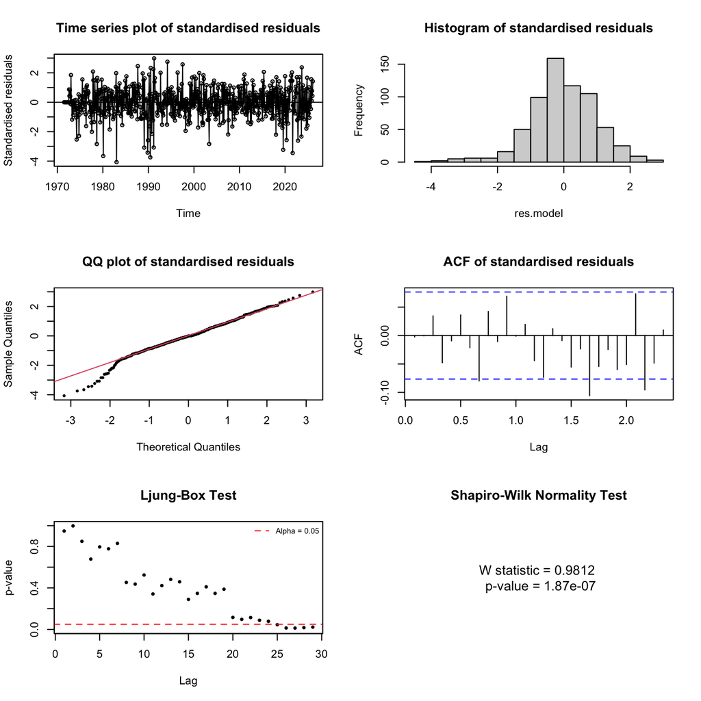

Figure 18: Residual diagnostics: M012 — SARIMA(0,1,2)(0,1,2)[12], CSS

```r
residuals_m012_css <- residual.analysis(m012_css, std = TRUE, model_class = "ARIMA")
```

### 6.0.2 M012: SARIMA$(0,1,2)(0,1,2)_{12}$ — ML

```r
make_coef_table(m012_ml, "Coefficients: M012 — SARIMA(0,1,2)(0,1,2)[12], ML")
```

Table 11: Coefficients: M012 — SARIMA(0,1,2)(0,1,2)[12], ML

Coefficients: M012 — SARIMA(0,1,2)(0,1,2)[12], ML

| Coefficient | Estimate | Std.Error | z.value | p.value | Sig |
| --- | --- | --- | --- | --- | --- |
| ma1 | -0.3595 | 0.0400 | -8.9976 | 0.0000 | *** |
| ma2 | -0.1236 | 0.0416 | -2.9711 | 0.0030 | ** |
| sma1 | -0.7769 | 0.0423 | -18.3811 | 0.0000 | *** |
| sma2 | -0.0121 | 0.0422 | -0.2861 | 0.7748 |  |

The ML estimation for the SARIMA$(0,1,2)(0,1,2)_{12}$ model yields an almost identical structural solution to the CSS estimation, confirming exceptional numerical stability and consistency across both optimization methods:

- *Non-Seasonal MA Terms*: Both ma1 (−0.3595, p<0.001) and ma2 (−0.1236, p=0.0030) remain highly significant with virtually unchanged coefficients and standard errors.
- *Seasonal MA Terms*: The seasonal structure mirrors the CSS profile exactly. The sma1 parameter remains highly significant and dominant (−0.7769, p<0.001), while sma2 stays entirely insignificant (−0.0121, p=0.7748).

The tight convergence between the CSS and ML estimates indicates a smooth, well-defined likelihood surface free of optimization anomalies. However, it also confirms that sma2 is structurally redundant across both methods, suggesting a more parsimonious SARIMA$(0,1,2)(0,1,1)_{12}$ model should be favored.

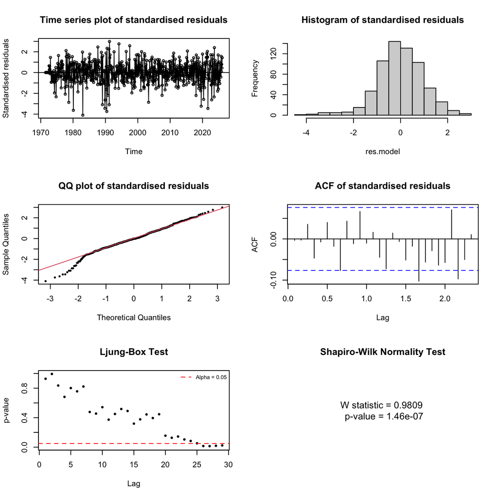

Figure 19: Residual diagnostics: M012 — SARIMA(0,1,2)(0,1,2)[12], ML

```r
residuals_m012_ml <- residual.analysis(m012_ml, std = TRUE, model_class = "ARIMA")
```

M012 (SARIMA$(0,1,2)(0,1,2)_{12}$) establishes itself as a viable early baseline benchmark, the first benchmark in the model comparison.

**Note**

**Parameter Estimates and Residual Diagnostics Framework**

To identify the optimal forecasting framework, candidate models undergo a rigorous, multi-stage evaluation process consisting of parameter estimation validation, residual diagnostics, and benchmark comparison.

1. **Parameters** for **each model are evaluated** using both Conditional Least Squares (CLS/CSS) and Maximum Likelihood (ML) estimation methods to ensure stability and convergence:
   - Estimation Alignment: If CSS and ML estimates yield consistent parameters, the model is deemed stable.
   - Discrepancy and Non-Convergence: In cases where CSS and ML estimation methods disagree, or if numerical non-convergence occurs, a combined CSS-ML approach is utilized as a third definitive test to resolve parameter instability and ensure optimization surface convergence.
2. **Residual Diagnostic Checking.** Every candidate model is subjected to thorough residual diagnostics to verify that the underlying statistical assumptions hold. This profile includes:
   - Autocorrelation Analysis: Examining Residual ACF and PACF plots alongside formal Ljung-Box test results to ensure the residuals behave as white noise and contain no remaining serial correlation.
   - Distributional Properties: Assessing residual histogram plots, QQ-plots, and Shapiro-Wilk tests to evaluate normality and check for variance stability.
3. Once the robust, validated candidate pool is established, the entire set of models is cross-examined against established baseline benchmarks.

### 6.0.3 M013: SARIMA$(0,1,3)(0,1,2)_{12}$ — CSS

**Note**

The detailed coefficient interpretations and residual diagnostics for this model are omitted, following the exact estimation, CSS/ML convergence checking, and residual diagnostic framework applied to the benchmark model.

```r
make_coef_table(m013_css, "Coefficients: M013 — SARIMA(0,1,3)(0,1,2)[12], CSS")
```

Table 12: Coefficients: M013 — SARIMA(0,1,3)(0,1,2)[12], CSS

Coefficients: M013 — SARIMA(0,1,3)(0,1,2)[12], CSS

| Coefficient | Estimate | Std.Error | z.value | p.value | Sig |
| --- | --- | --- | --- | --- | --- |
| ma1 | -0.3561 | 0.0396 | -8.9821 | 0.0000 | *** |
| ma2 | -0.1332 | 0.0442 | -3.0112 | 0.0026 | ** |
| ma3 | 0.0171 | 0.0395 | 0.4332 | 0.6649 |  |
| sma1 | -0.7834 | 0.0424 | -18.4701 | 0.0000 | *** |
| sma2 | -0.0112 | 0.0423 | -0.2655 | 0.7907 |  |

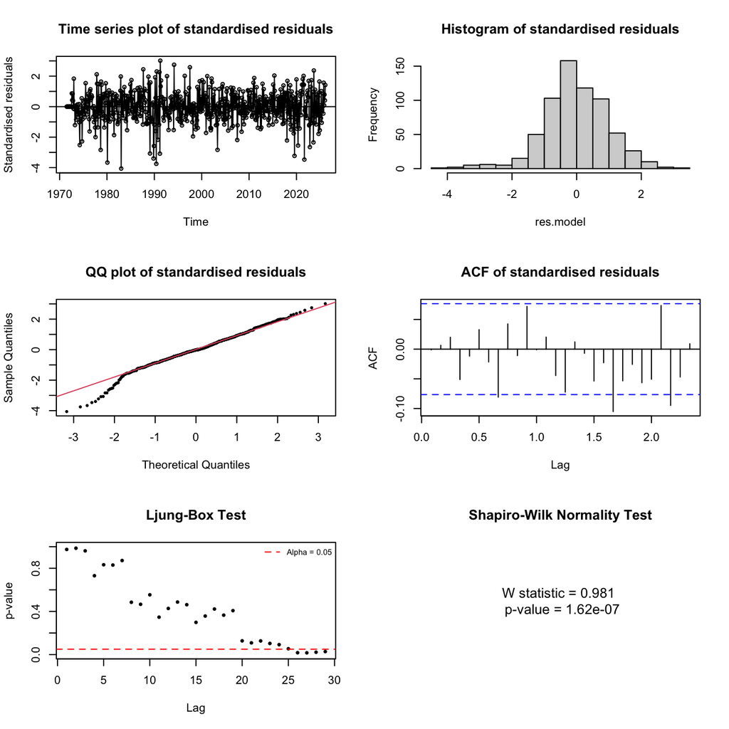

Figure 20: Residual diagnostics: M013 — SARIMA(0,1,3)(0,1,2)[12], CSS

```r
residuals_m013_css <- residual.analysis(m013_css, std = TRUE, model_class = "ARIMA")
```

### 6.0.4 M013: SARIMA$(0,1,3)(0,1,2)_{12}$ — ML

**Note**

The detailed coefficient interpretations and residual diagnostics for this model are omitted, following the exact estimation, CSS/ML convergence checking, and residual diagnostic framework applied to the benchmark model.

```r
make_coef_table(m013_ml, "Coefficients: M013 — SARIMA(0,1,3)(0,1,2)[12], ML")
```

Table 13: Coefficients: M013 — SARIMA(0,1,3)(0,1,2)[12], ML

Coefficients: M013 — SARIMA(0,1,3)(0,1,2)[12], ML

| Coefficient | Estimate | Std.Error | z.value | p.value | Sig |
| --- | --- | --- | --- | --- | --- |
| ma1 | -0.3600 | 0.0396 | -9.0943 | 0.0000 | *** |
| ma2 | -0.1318 | 0.0441 | -2.9914 | 0.0028 | ** |
| ma3 | 0.0203 | 0.0394 | 0.5165 | 0.6055 |  |
| sma1 | -0.7763 | 0.0423 | -18.3695 | 0.0000 | *** |
| sma2 | -0.0116 | 0.0422 | -0.2740 | 0.7841 |  |

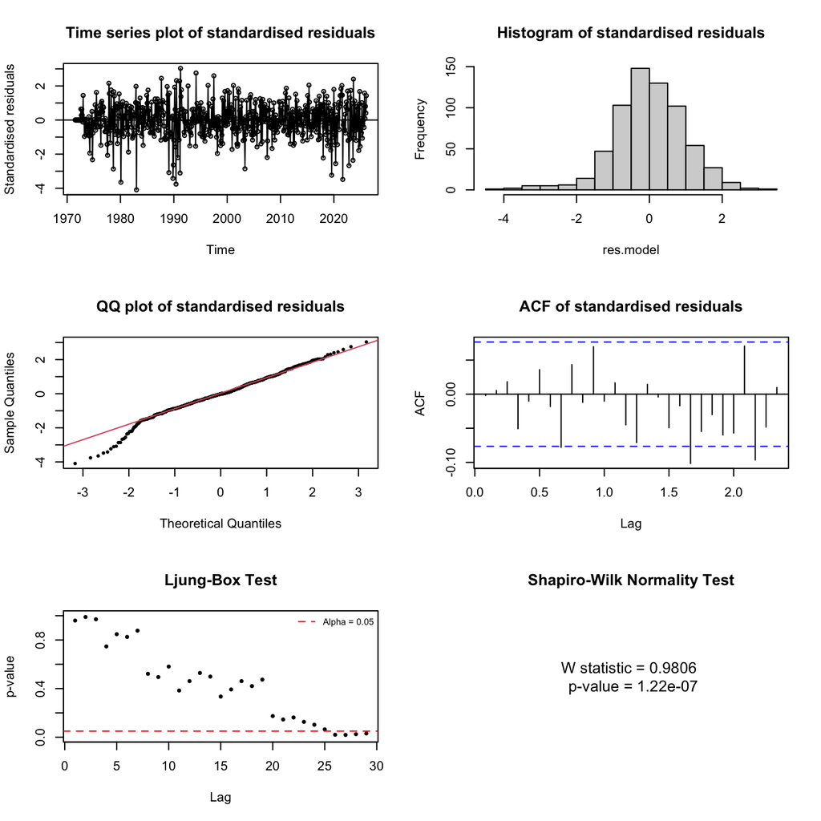

Figure 21: Residual diagnostics: M013 — SARIMA(0,1,3)(0,1,2)[12], ML

```r
residuals_m013_ml <- residual.analysis(m013_ml, std = TRUE, model_class = "ARIMA")
```

### 6.0.5 M111: SARIMA$(1,1,1)(0,1,2)_{12}$ — CSS

```r
make_coef_table(m111_css, "Coefficients: M111 — SARIMA(1,1,1)(0,1,2)[12], CSS")
```

Table 14: Coefficients: M111 — SARIMA(1,1,1)(0,1,2)[12], CSS

Coefficients: M111 — SARIMA(1,1,1)(0,1,2)[12], CSS

| Coefficient | Estimate | Std.Error | z.value | p.value | Sig |
| --- | --- | --- | --- | --- | --- |
| ar1 | 0.2398 | 0.0840 | 2.8552 | 0.0043 | ** |
| ma1 | -0.6061 | 0.0685 | -8.8468 | 0.0000 | *** |
| sma1 | -0.7756 | 0.0420 | -18.4615 | 0.0000 | *** |
| sma2 | -0.0152 | 0.0420 | -0.3612 | 0.7180 |  |

The CSS estimation for the SARIMA$(1,1,1)(0,1,2)_{12}$ model demonstrates strong statistical significance across most of its components, transitioning from a pure MA specification (M012/M013) to a mixed ARMA structure:

- *Non-Seasonal AR/MA Terms*: Both the autoregressive term ar1 (0.2398, p=0.0043) and the moving average term ma1 (−0.6061, p<0.001) are highly significant. This confirms that introducing a mixed structure robustly captures short-term residual dependencies.
- *Seasonal MA Terms*: The seasonal moving average structure mirrors the over-parameterization pattern seen in previous iterations. The first-order seasonal term sma1 remains highly significant and structurally dominant (−0.7756, p<0.001), while the second-order term sma2 (−0.0152, p=0.7180) remains completely insignificant.

Except for the redundant sma2 term, the remaining parameters are cleanly identified with tight standard errors relative to their estimates, indicating a stable parameter solution.

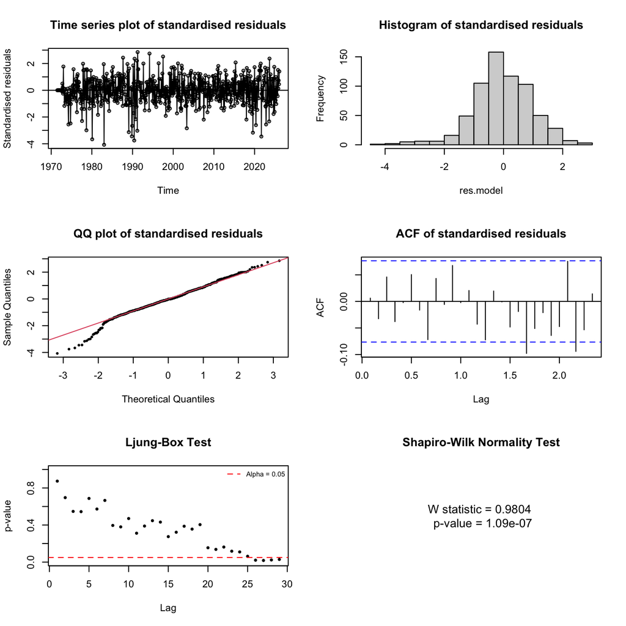

Figure 22: Residual diagnostics: M111 — SARIMA(1,1,1)(0,1,2)[12], CSS

```r
residuals_m111_css <- residual.analysis(m111_css, std = TRUE, model_class = "ARIMA")
```

- *Time Series Plot*: The standardized residuals fluctuate cleanly around zero with no apparent deterministic trend or remaining seasonal patterns. The series highlights two distinct shock eras exhibiting larger negative excursions reaching down near −4. Outside of these volatile periods, there is no evidence of systematic variance clustering.
- *Histogram*: The distribution is roughly symmetric and well-centered near zero. It exhibits a slight left-skew with a longer left tail, which is entirely consistent with the occasional large negative historical shocks visible in the time series plot.
- *Q-Q Plot*: The majority of the empirical distribution (spanning from roughly −2 to +3) tracks the theoretical normal reference line tightly. The primary normality concern remains the clear lower-tail deviation, where several data points pull away sharply below the −2 theoretical quantile mark due to the 1980s and 2020s historical outliers.
- *ACF Plot*: Almost identical to CSS M012/M013. The residual autocorrelation profile remains clean overall, with a few prominent, statistically significant spikes observed breaching the 5% confidence bands.
- *Ljung-Box Test*: P-values start exceptionally high (above 0.85) and remain above the 0.05 significance threshold through lag 20. However, they plunge sharply after lag 20, crossing below the 0.05 threshold around lags 25–26 and remaining significant through lag 30, showing that long-term white noise properties are compromised.
- *Shapiro-Wilk Test*: The test yields a p<0.05. This formally rejects the null hypothesis of normality.

### 6.0.6 M111: SARIMA$(1,1,1)(0,1,2)_{12}$ — ML

```r
make_coef_table(m111_ml, "Coefficients: M111 — SARIMA(1,1,1)(0,1,2)[12], ML")
```

Table 15: Coefficients: M111 — SARIMA(1,1,1)(0,1,2)[12], ML

Coefficients: M111 — SARIMA(1,1,1)(0,1,2)[12], ML

| Coefficient | Estimate | Std.Error | z.value | p.value | Sig |
| --- | --- | --- | --- | --- | --- |
| ar1 | 0.2555 | 0.0877 | 2.9116 | 0.0036 | ** |
| ma1 | -0.6237 | 0.0710 | -8.7777 | 0.0000 | *** |
| sma1 | -0.7758 | 0.0422 | -18.3995 | 0.0000 | *** |
| sma2 | -0.0137 | 0.0420 | -0.3262 | 0.7443 |  |

The ML estimation for the SARIMA$(1,1,1)(0,1,2)_{12}$ model yields an exceptionally stable and consistent solution compared to its CSS counterpart, confirming strong numerical convergence:

- *Non-Seasonal AR/MA Terms*: Both ar1 (0.2555, p=0.0036) and ma1 (−0.6237, p<0.001) remain highly significant. Their estimates and tight standard errors are nearly identical to the CSS results, verifying a robust capture of short-term residual dependencies.
- *Seasonal MA Terms*: The structural over-parameterization issue persists precisely as observed under CSS. The first-order seasonal term sma1 remains highly significant and dominant (−0.7758, p<0.001), while the second-order seasonal term sma2 (−0.0137, p=0.7443) remains entirely insignificant.

The negligible variance between the CSS and ML parameter estimates points to a smooth, well-defined likelihood surface, though it confirms that sma2 is redundant and should be omitted for a more parsimonious model design.

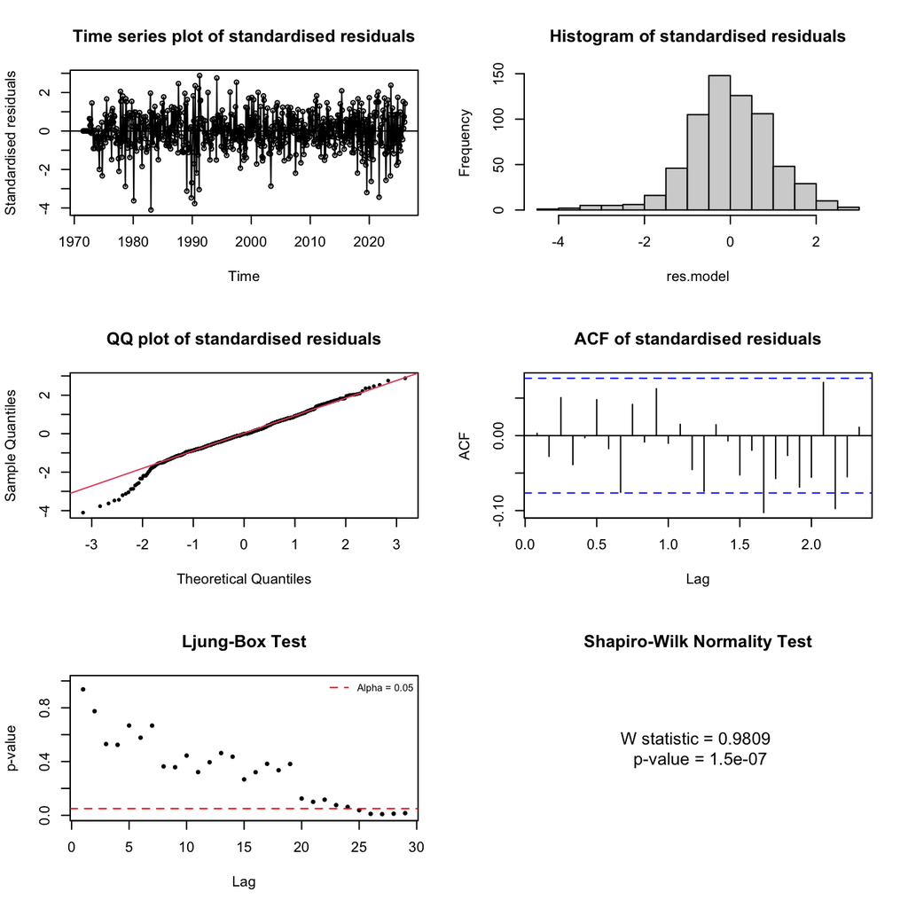

Figure 23: Residual diagnostics: M111 — SARIMA(1,1,1)(0,1,2)[12], ML

```r
residuals_m111_ml <- residual.analysis(m111_ml, std = TRUE, model_class = "ARIMA")
```

While M012 establishes itself as a viable early baseline benchmark, M111 emerges as the more structurally efficient model that approximately satisfies residual independence at the diagnostically important short-to-medium lags. **Consequently, M111 supersedes M012 to become a refined benchmark.**

### 6.0.7 M112: SARIMA$(1,1,2)(0,1,2)_{12}$ — CSS

**Note**

The detailed coefficient interpretations and residual diagnostics for this model are omitted, following the exact estimation, CSS/ML convergence checking, and residual diagnostic framework applied to the benchmark model.

```r
make_coef_table(m112_css, "Coefficients: M112 — SARIMA(1,1,2)(0,1,2)[12], CSS")
```

Table 16: Coefficients: M112 — SARIMA(1,1,2)(0,1,2)[12], CSS

Coefficients: M112 — SARIMA(1,1,2)(0,1,2)[12], CSS

| Coefficient | Estimate | Std.Error | z.value | p.value | Sig |
| --- | --- | --- | --- | --- | --- |
| ar1 | -0.3047 | 0.2963 | -1.0284 | 0.3038 |  |
| ma1 | -0.0537 | 0.2909 | -0.1846 | 0.8535 |  |
| ma2 | -0.2435 | 0.1127 | -2.1613 | 0.0307 | * |
| sma1 | -0.7787 | 0.0423 | -18.4040 | 0.0000 | *** |
| sma2 | -0.0104 | 0.0422 | -0.2475 | 0.8045 |  |

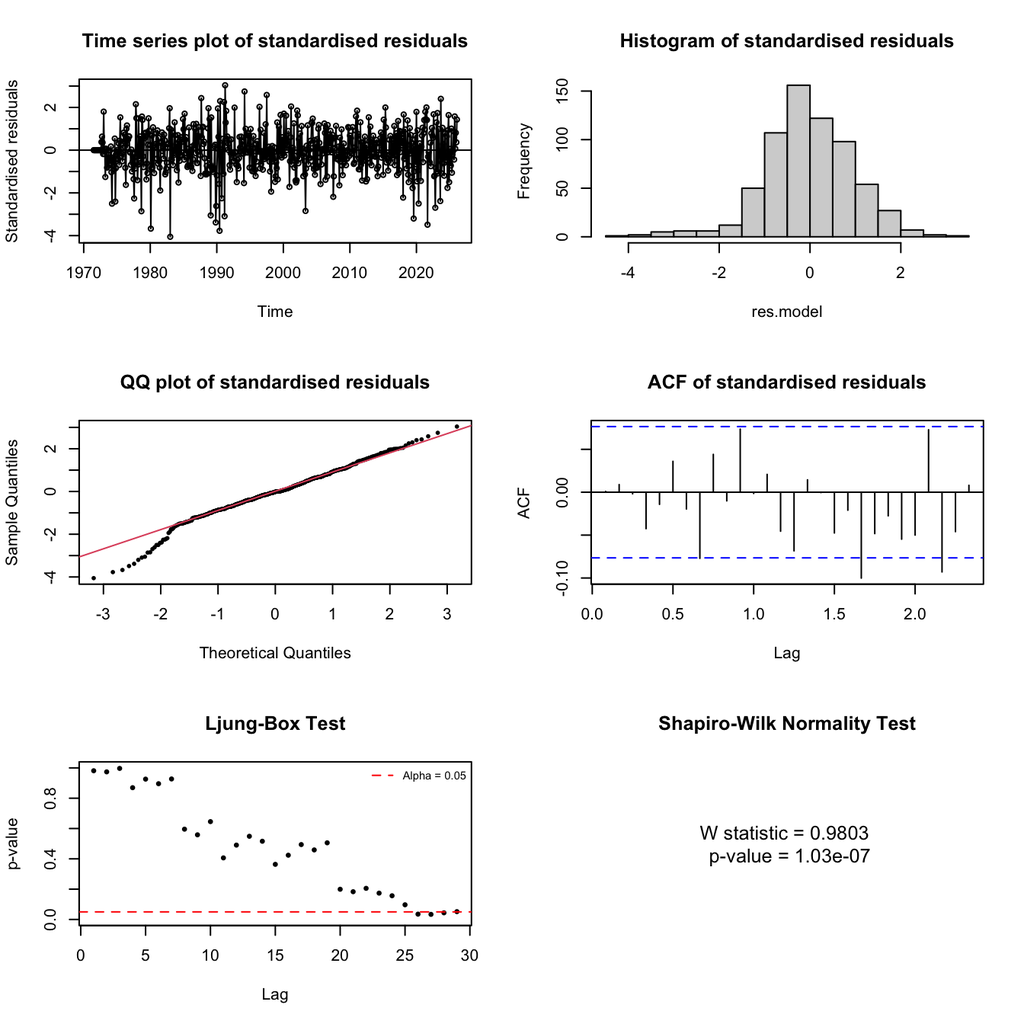

Figure 24: Residual diagnostics: M112 — SARIMA(1,1,2)(0,1,2)[12], CSS

```r
residuals_m112_css <- residual.analysis(m112_css, std = TRUE, model_class = "ARIMA")
```

### 6.0.8 M112: SARIMA$(1,1,2)(0,1,2)_{12}$ — ML

**Note**

The detailed coefficient interpretations and residual diagnostics for this model are omitted, following the exact estimation, CSS/ML convergence checking, and residual diagnostic framework applied to the benchmark model.

```r
make_coef_table(m112_ml, "Coefficients: M112 — SARIMA(1,1,2)(0,1,2)[12], ML")
```

Table 17: Coefficients: M112 — SARIMA(1,1,2)(0,1,2)[12], ML

Coefficients: M112 — SARIMA(1,1,2)(0,1,2)[12], ML

| Coefficient | Estimate | Std.Error | z.value | p.value | Sig |
| --- | --- | --- | --- | --- | --- |
| ar1 | -0.3568 | 0.3681 | -0.9693 | 0.3324 |  |
| ma1 | -0.0062 | 0.3604 | -0.0171 | 0.9863 |  |
| ma2 | -0.2636 | 0.1349 | -1.9539 | 0.0507 |  |
| sma1 | -0.7761 | 0.0422 | -18.3906 | 0.0000 | *** |
| sma2 | -0.0112 | 0.0421 | -0.2650 | 0.7910 |  |

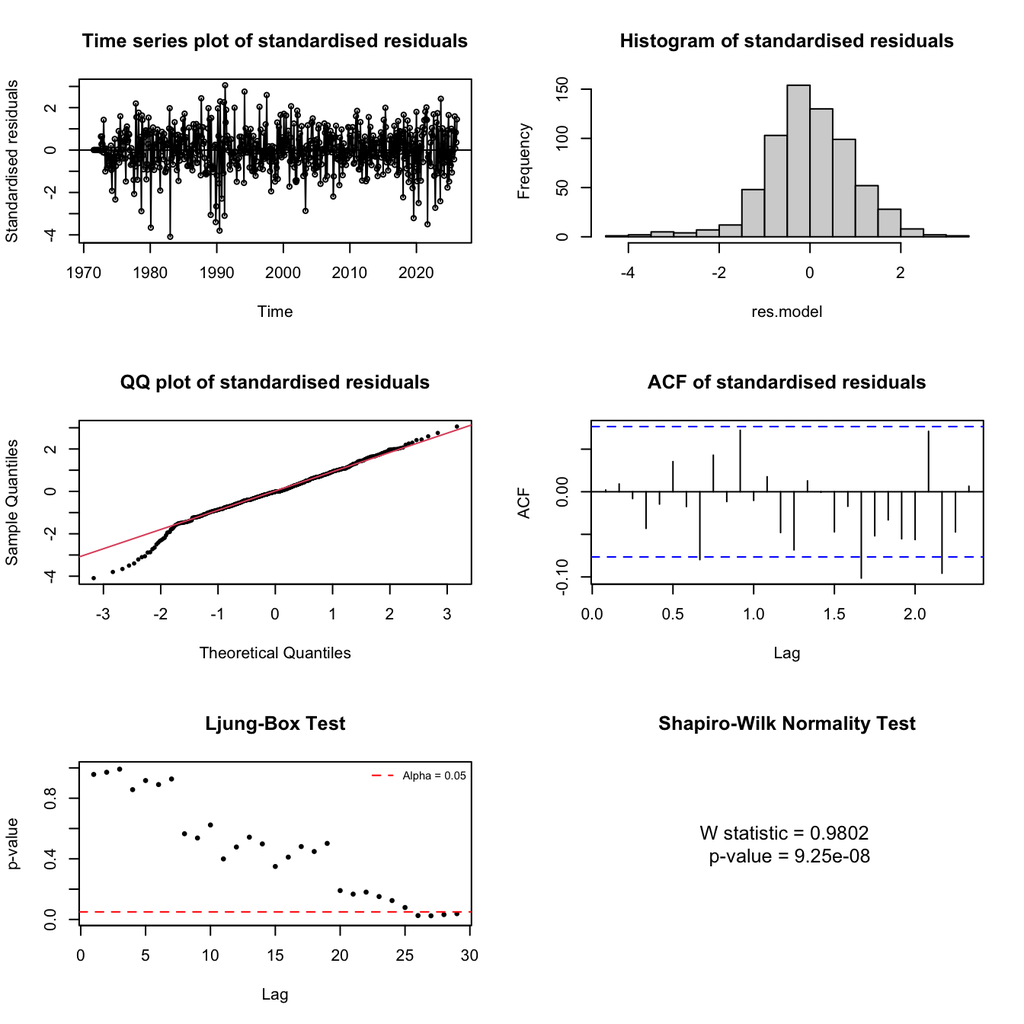

Figure 25: Residual diagnostics: M112 — SARIMA(1,1,2)(0,1,2)[12], ML

```r
residuals_m112_ml <- residual.analysis(m112_ml, std = TRUE, model_class = "ARIMA")
```

### 6.0.9 M112: SARIMA$(1,1,2)(0,1,2)_{12}$ — CSS-ML

**Note**

The detailed coefficient interpretations and residual diagnostics for this model are omitted, following the exact estimation, CSS/ML convergence checking, and residual diagnostic framework applied to the benchmark model.

```r
make_coef_table(m112_cssml, "Coefficients: M112 — SARIMA(1,1,2)(0,1,2)[12], CSS-ML")
```

Table 18: Coefficients: M112 — SARIMA(1,1,2)(0,1,2)[12], CSS-ML

Coefficients: M112 — SARIMA(1,1,2)(0,1,2)[12], CSS-ML

| Coefficient | Estimate | Std.Error | z.value | p.value | Sig |
| --- | --- | --- | --- | --- | --- |
| ar1 | -0.3566 | 0.3681 | -0.9688 | 0.3326 |  |
| ma1 | -0.0063 | 0.3604 | -0.0176 | 0.9860 |  |
| ma2 | -0.2636 | 0.1349 | -1.9531 | 0.0508 |  |
| sma1 | -0.7761 | 0.0422 | -18.3904 | 0.0000 | *** |
| sma2 | -0.0112 | 0.0421 | -0.2650 | 0.7910 |  |

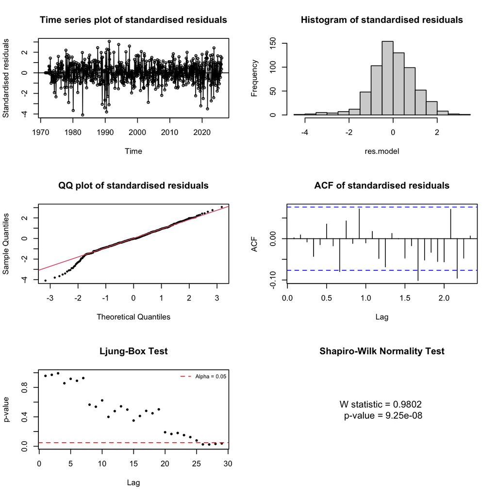

Figure 26: Residual diagnostics: M112 — SARIMA(1,1,2)(0,1,2)[12], CSS-ML

```r
residuals_m112_cssml <- residual.analysis(m112_cssml, std = TRUE, model_class = "ARIMA")
```

### 6.0.10 M113: SARIMA$(1,1,3)(0,1,2)_{12}$ — CSS

**Note**

The detailed coefficient interpretations and residual diagnostics for this model are omitted, following the exact estimation, CSS/ML convergence checking, and residual diagnostic framework applied to the benchmark model.

```r
make_coef_table(m113_css, "Coefficients: M113 — SARIMA(1,1,3)(0,1,2)[12], CSS")
```

Table 19: Coefficients: M113 — SARIMA(1,1,3)(0,1,2)[12], CSS

Coefficients: M113 — SARIMA(1,1,3)(0,1,2)[12], CSS

| Coefficient | Estimate | Std.Error | z.value | p.value | Sig |
| --- | --- | --- | --- | --- | --- |
| ar1 | -0.3943 | 0.4186 | -0.9421 | 0.3462 |  |
| ma1 | 0.0365 | 0.4176 | 0.0873 | 0.9304 |  |
| ma2 | -0.2753 | 0.1542 | -1.7853 | 0.0742 |  |
| ma3 | -0.0161 | 0.0610 | -0.2643 | 0.7915 |  |
| sma1 | -0.7791 | 0.0423 | -18.3992 | 0.0000 | *** |
| sma2 | -0.0105 | 0.0422 | -0.2482 | 0.8040 |  |

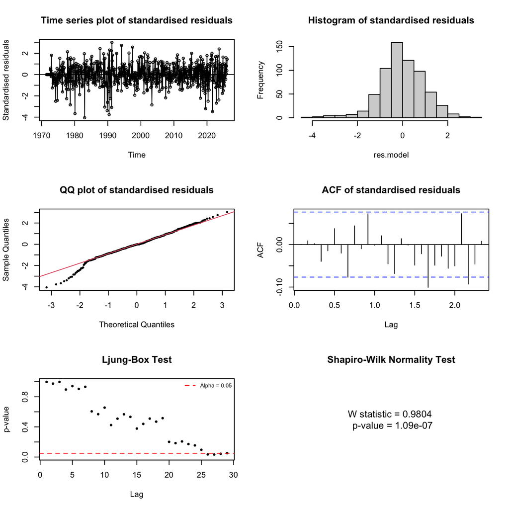

Figure 27: Residual diagnostics: M113 — SARIMA(1,1,3)(0,1,2)[12], CSS

```r
residuals_m113_css <- residual.analysis(m113_css, std = TRUE, model_class = "ARIMA")
```

### 6.0.11 M113: SARIMA$(1,1,3)(0,1,2)_{12}$ — ML

**Note**

The detailed coefficient interpretations and residual diagnostics for this model are omitted, following the exact estimation, CSS/ML convergence checking, and residual diagnostic framework applied to the benchmark model.

```r
make_coef_table(m113_ml, "Coefficients: M113 — SARIMA(1,1,3)(0,1,2)[12], ML")
```

Table 20: Coefficients: M113 — SARIMA(1,1,3)(0,1,2)[12], ML

Coefficients: M113 — SARIMA(1,1,3)(0,1,2)[12], ML

| Coefficient | Estimate | Std.Error | z.value | p.value | Sig |
| --- | --- | --- | --- | --- | --- |
| ar1 | -0.9248 | 0.0498 | -18.5607 | 0.0000 | *** |
| ma1 | 0.5711 | 0.0647 | 8.8295 | 0.0000 | *** |
| ma2 | -0.4681 | 0.0443 | -10.5613 | 0.0000 | *** |
| ma3 | -0.0845 | 0.0460 | -1.8387 | 0.0660 |  |
| sma1 | -0.7605 | 0.0428 | -17.7574 | 0.0000 | *** |
| sma2 | -0.0218 | 0.0425 | -0.5140 | 0.6072 |  |

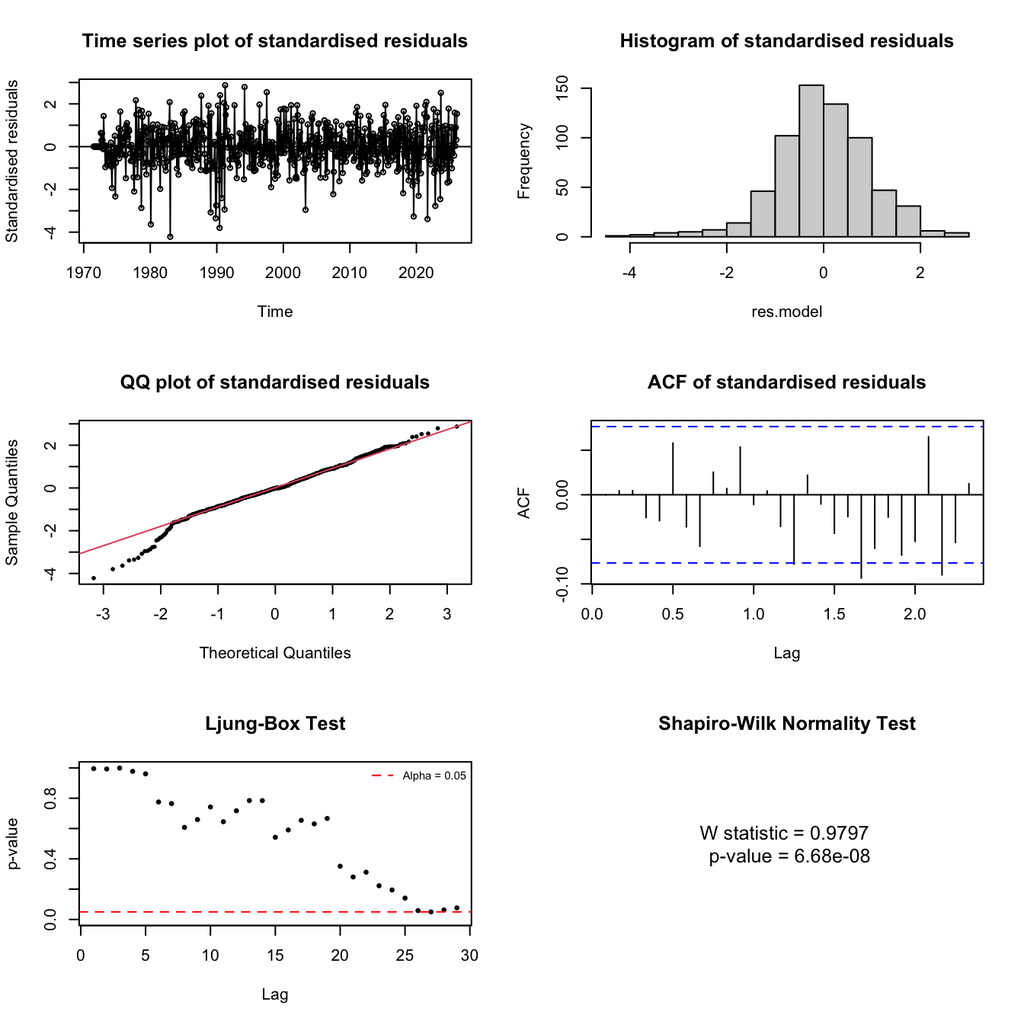

Figure 28: Residual diagnostics: M113 — SARIMA(1,1,3)(0,1,2)[12], ML

```r
residuals_m113_ml <- residual.analysis(m113_ml, std = TRUE, model_class = "ARIMA")
```

### 6.0.12 M113: SARIMA$(1,1,3)(0,1,2)_{12}$ — CSS-ML

**Note**

The detailed coefficient interpretations and residual diagnostics for this model are omitted, following the exact estimation, CSS/ML convergence checking, and residual diagnostic framework applied to the benchmark model.

```r
make_coef_table(m113_cssml, "Coefficients: M113 — SARIMA(1,1,3)(0,1,2)[12], CSS-ML")
```

Table 21: Coefficients: M113 — SARIMA(1,1,3)(0,1,2)[12], CSS-ML

Coefficients: M113 — SARIMA(1,1,3)(0,1,2)[12], CSS-ML

| Coefficient | Estimate | Std.Error | z.value | p.value | Sig |
| --- | --- | --- | --- | --- | --- |
| ar1 | -0.9248 | 0.0498 | -18.5574 | 0.0000 | *** |
| ma1 | 0.5711 | 0.0647 | 8.8287 | 0.0000 | *** |
| ma2 | -0.4681 | 0.0443 | -10.5610 | 0.0000 | *** |
| ma3 | -0.0845 | 0.0460 | -1.8386 | 0.0660 |  |
| sma1 | -0.7605 | 0.0428 | -17.7580 | 0.0000 | *** |
| sma2 | -0.0218 | 0.0425 | -0.5135 | 0.6076 |  |

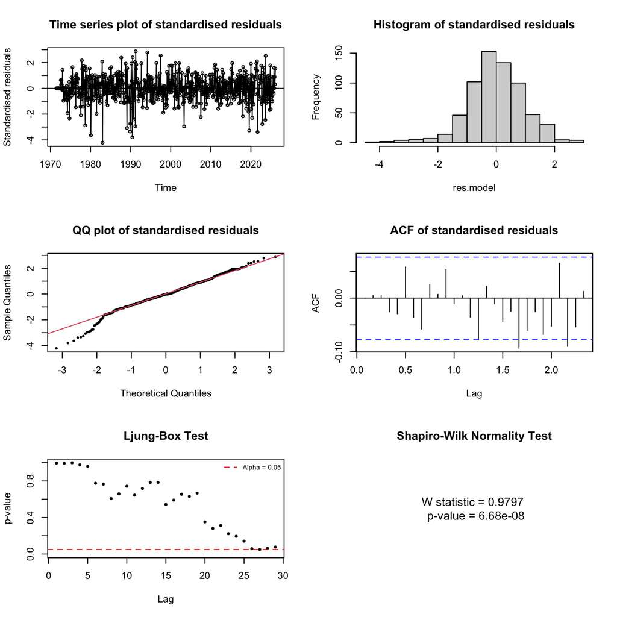

Figure 29: Residual diagnostics: M113 — SARIMA(1,1,3)(0,1,2)[12], CSS-ML

```r
residuals_m113_cssml <- residual.analysis(m113_cssml, std = TRUE, model_class = "ARIMA")
```

### 6.0.13 M211: SARIMA$(2,1,1)(0,1,2)_{12}$ — CSS

**Note**

The detailed coefficient interpretations and residual diagnostics for this model are omitted, following the exact estimation, CSS/ML convergence checking, and residual diagnostic framework applied to the benchmark model.

```r
make_coef_table(m211_css, "Coefficients: M211 — SARIMA(2,1,1)(0,1,2)[12], CSS")
```

Table 22: Coefficients: M211 — SARIMA(2,1,1)(0,1,2)[12], CSS

Coefficients: M211 — SARIMA(2,1,1)(0,1,2)[12], CSS

| Coefficient | Estimate | Std.Error | z.value | p.value | Sig |
| --- | --- | --- | --- | --- | --- |
| ar1 | 0.1719 | 0.1467 | 1.1715 | 0.2414 |  |
| ar2 | -0.0547 | 0.0687 | -0.7960 | 0.4260 |  |
| ma1 | -0.5310 | 0.1430 | -3.7130 | 0.0002 | *** |
| sma1 | -0.7771 | 0.0423 | -18.3847 | 0.0000 | *** |
| sma2 | -0.0125 | 0.0422 | -0.2968 | 0.7666 |  |

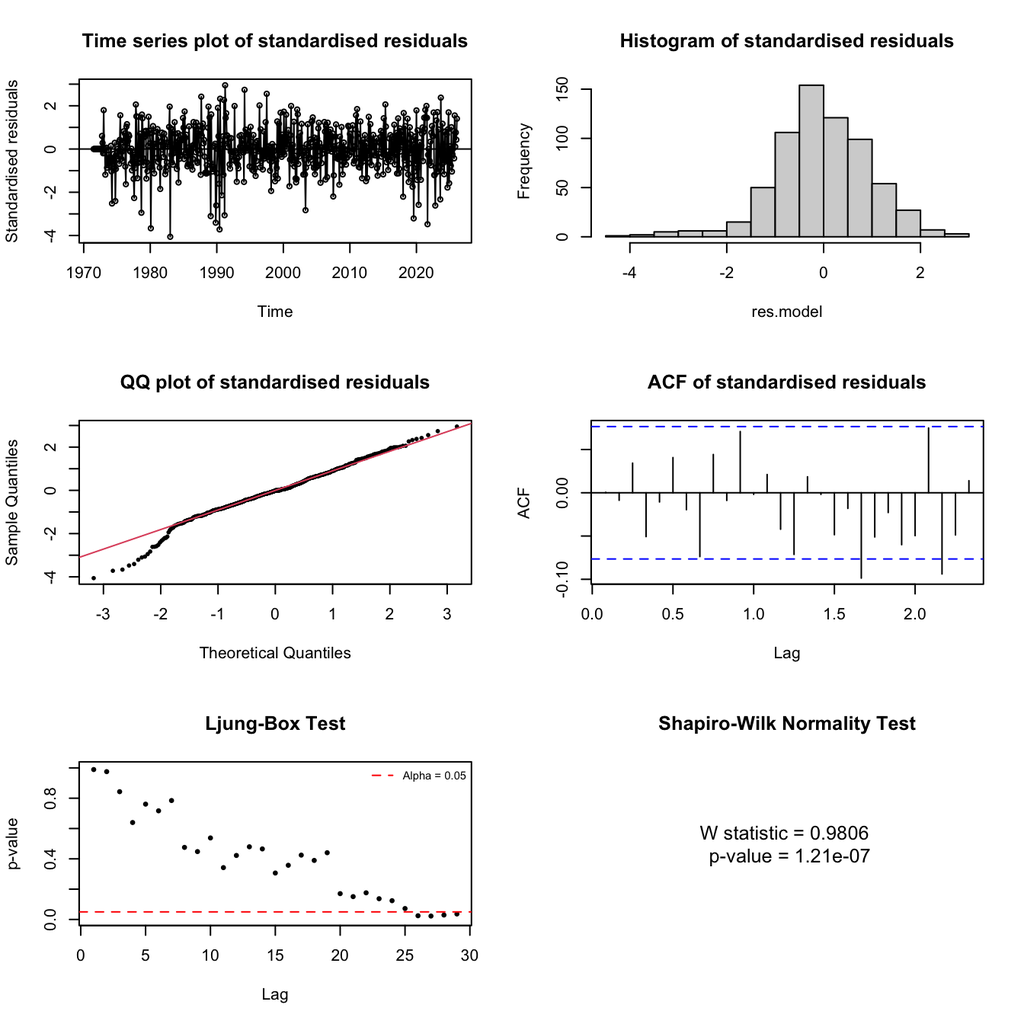

Figure 30: Residual diagnostics: M211 — SARIMA(2,1,1)(0,1,2)[12], CSS

```r
residuals_m211_css <- residual.analysis(m211_css, std = TRUE, model_class = "ARIMA")
```

### 6.0.14 M211: SARIMA$(2,1,1)(0,1,2)_{12}$ — ML

**Note**

The detailed coefficient interpretations and residual diagnostics for this model are omitted, following the exact estimation, CSS/ML convergence checking, and residual diagnostic framework applied to the benchmark model.

```r
make_coef_table(m211_ml, "Coefficients: M211 — SARIMA(2,1,1)(0,1,2)[12], ML")
```

Table 23: Coefficients: M211 — SARIMA(2,1,1)(0,1,2)[12], ML

Coefficients: M211 — SARIMA(2,1,1)(0,1,2)[12], ML

| Coefficient | Estimate | Std.Error | z.value | p.value | Sig |
| --- | --- | --- | --- | --- | --- |
| ar1 | 0.1802 | 0.1490 | 1.2098 | 0.2264 |  |
| ar2 | -0.0502 | 0.0705 | -0.7124 | 0.4762 |  |
| ma1 | -0.5441 | 0.1455 | -3.7390 | 0.0002 | *** |
| sma1 | -0.7755 | 0.0422 | -18.3644 | 0.0000 | *** |
| sma2 | -0.0127 | 0.0421 | -0.3022 | 0.7625 |  |

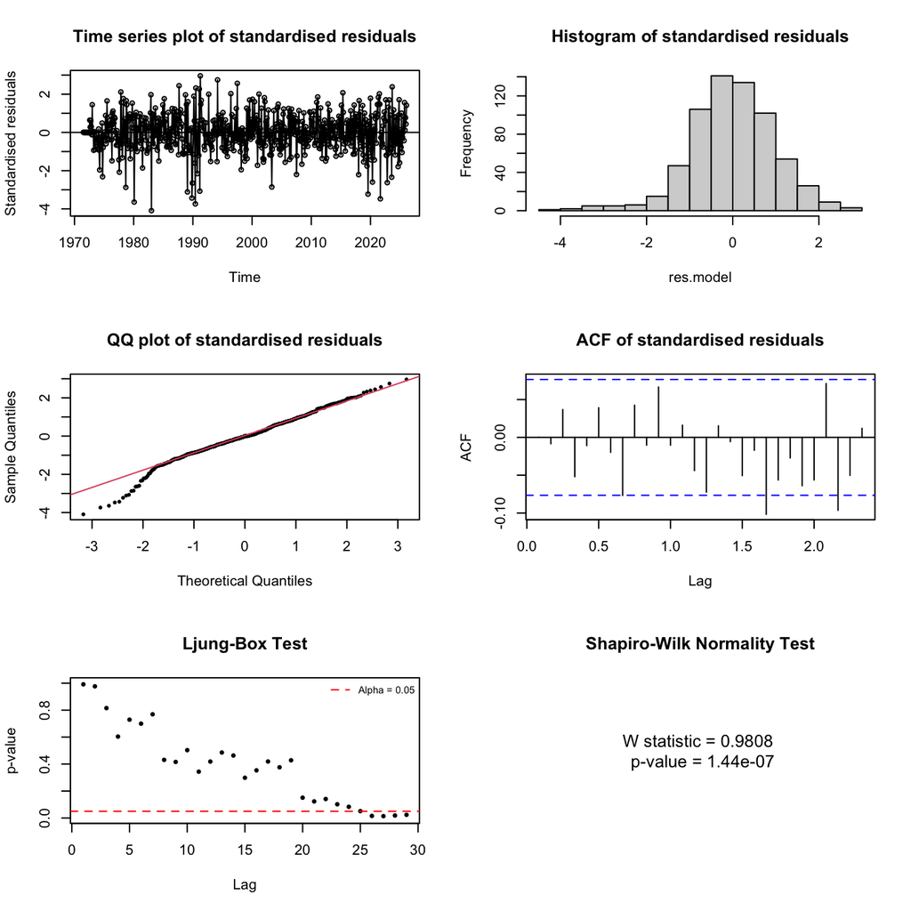

Figure 31: Residual diagnostics: M211 — SARIMA(2,1,1)(0,1,2)[12], ML

```r
residuals_m211_ml <- residual.analysis(m211_ml, std = TRUE, model_class = "ARIMA")
```

### 6.0.15 M212: SARIMA$(2,1,2)(0,1,2)_{12}$ — CSS

```r
make_coef_table(m212_css, "Coefficients: M212 — SARIMA(2,1,2)(0,1,2)[12], CSS")
```

Table 24: Coefficients: M212 — SARIMA(2,1,2)(0,1,2)[12], CSS

Coefficients: M212 — SARIMA(2,1,2)(0,1,2)[12], CSS

| Coefficient | Estimate | Std.Error | z.value | p.value | Sig |
| --- | --- | --- | --- | --- | --- |
| ar1 | -0.7693 | 0.0931 | -8.2644 | 0.0000 | *** |
| ar2 | 0.1423 | 0.0813 | 1.7499 | 0.0801 |  |
| ma1 | 0.4110 | 0.0825 | 4.9846 | 0.0000 | *** |
| ma2 | -0.5391 | 0.0723 | -7.4544 | 0.0000 | *** |
| sma1 | -0.7582 | 0.0426 | -17.8037 | 0.0000 | *** |
| sma2 | -0.0262 | 0.0423 | -0.6182 | 0.5364 |  |

- *Non- Seasonal AR/MA Terms*: The first order AR term AR1 is highly efficient, which indicates a strong autocorrelation at lag 1. The second order AR2 is **not statistically significant** (0.1423, p = 0.0801), exceeding the 0.05 threshold. This shows that the AR(2) term may be redundant. Both MA terms are highly significant where ma1 (0.4110, p<0.001) and ma2 (-0.5391, p <0.001). Which indicates that the MA(2) structure is well supported by the series.
- *Seasonal MA Terms*: The first-order seasonal MA term SMA1 is highly significant (−0.7582, p < 0.001), this confirm its dominant role in capturing seasonal dependence. The second-order seasonal moving average term sma2 is not statistically significant (−0.0262, p = 0.5364), remaining redundant and contributing no meaningful explanatory power.

Most coefficient are statistically significant, with the exception of sma2 (p=0.5364). The ar2 coefficient is borderline (p=0.0801). Despite these marginal insignificances, the model is retained for further evaluation and residuals diagnostics including ACF, Ljung Box test, and normality test will determine whether this model is adequate for forecasting.

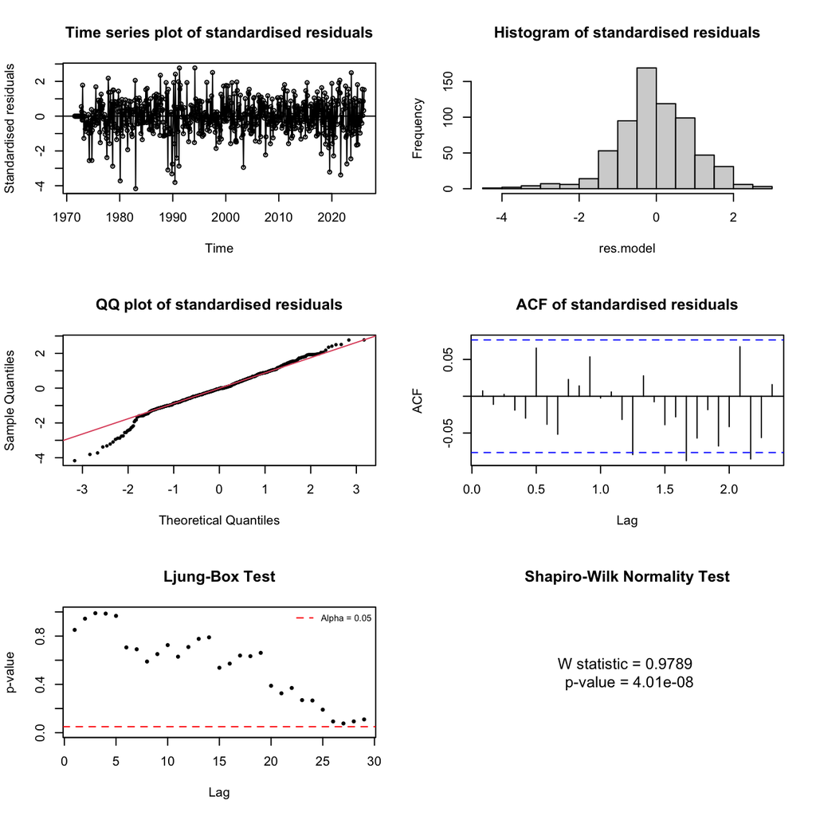

Figure 32: Residual diagnostics: M212 — SARIMA(2,1,2)(0,1,2)[12], CSS

```r
residuals_m212_css <- residual.analysis(m212_css, std = TRUE, model_class = "ARIMA")
```